# Summarize updated MT-DNA results (SNP- and Gene-based)

23 February, 2026

```r
# devtools::install_github("PheWAS/PheWAS")
# devtools::install_github("camillemmoore/Power_Genetics", subdir="genpwr")

library(PheWAS)
library(tidyverse)
library(plotly)
library(forestplot)
library(geomtextpath)
library(colorspace)
library(scales)
library(grid)
#library(khroma)
library(formatdown)
library(data.table)
#library(ComplexUpset)
library(knitr)
library(magrittr)
library(readxl)
library(ggrepel)
library(stringi)
library(officer)
library(flextable)
library(openxlsx)
library(httr)
library(jsonlite)
library(logistf)
library(genpwr)
library(cowplot)
library(magick)
library(DiagrammeR)
library(DiagrammeRsvg)
library(rsvg)
```

```r
# define folder directories
dir <- "C:/Users/aubre/Box/MT-MVP/"
analysis_dir <- paste0(dir, "/analysis/updated/2025Rerun/")
egress_dir <- paste0(analysis_dir, "egress/")
data_dir2 <- paste0(egress_dir, "20251014/")
data_dir3 <- paste0(egress_dir, "20251201/")
input_dir <- paste0(analysis_dir, "mt_input_clean/")
output_dir <- paste0(analysis_dir, "mt_output_clean/")
image_dir <- paste0(output_dir, "images/")
dir.create(image_dir, recursive = T, showWarnings = FALSE)
```

## Load Info

```r
d_gene_all <- fread(paste0(input_dir, "results_mvp_genebased_all_2025.csv"),
                  colClasses = c("phecode" = "character"))
d_snp_all <- fread(paste0(input_dir, "results_mvp_snpbased_all_2025.csv"),
                  colClasses = c("phecode" = "character"))
intx_sex <- fread(paste0(data_dir2, "intx_result_sex_2025.csv"),
                  colClasses = c("phecode" = "character"))
intx_t2d <- fread(paste0(data_dir2, "intx_result_t2d_2025.csv"),
                  colClasses = c("phecode" = "character"))
all_afreqs <- fread(paste0(input_dir, "mvp_afreqs_all_2025.csv"))
UKB_repl <- fread(paste0(input_dir, "results_ukb_replication.csv"),
                  colClasses = c("phecode" = "character"))
snps_in_SetIDs <- fread(paste0(input_dir, "snps_in_SetIDs.csv"))
flowchart_data <- fread(paste0(data_dir2, "flowchart_data.txt"))
extendedPheWAS <- fread(paste0(data_dir3, "MTextendedPheWAS_2025.txt"))
```

Load MT base info for solar plots

```r
#Gene boundaries
refflat <- fread(paste0(analysis_dir,
                  "../summary/gene_definitions/gencode_mt_refFlat.txt")) %>%
  select(1, 5, 6) %>%
  set_names(c("gene", "start", "end")) %>%
  mutate(gene = gsub("MT-", "", gene)) %>%
  # refflat is 0-based, whereas chip and mitomap are 1-based
  # also, 'end' is exclusive
  # add +1 to 'start' before joining to snp data
  # keep 'end' the same (+ 1 -1) to make inclusive
  mutate(start = start + 1)
```

## Define data encoding keys and color schema for plots

Define data encoding keys

```r
biomarker_key <- c(
  "a1c" = "HbA1c",
  "tg_adj_INT" = "Triglycerides",
  "ldlc_adj_INT" = "LDL",
  "hdlc_adj_INT" = "HDL",
  "sbp_adj" = "Systolic BP",
  "dbp_adj" = "Diastolic BP",
  "bmi_obese" = "Obesity (BMI >= 30)",
  "bmi" = "Body Mass Index",
  "phecodes" = "PheCodes",
  "tg.adj.INT" = "Triglycerides",
  "ldlc.adj.INT" = "LDL",
  "hdlc.adj.INT" = "HDL",
  "sbp.adj" = "Systolic BP",
  "dbp.adj" = "Diastolic BP",
  "bmi.obese" = "Obesity (BMI >= 30)"
)
```

# Table 1

```r
table1a <- fread(paste0(data_dir2, "table1a.txt"), dec = ".")
table1b <- fread(paste0(data_dir2, "table1b.txt"), dec = ".")
table1c <- fread(paste0(data_dir2, "table1c.txt"), dec = ".")

names(table1b) <- gsub("EUR|AFR|AMR|EAS|_", "", names(table1b))
names(table1c) <- gsub("EUR|AFR|AMR|EAS|_", "", names(table1c))
names(table1c) <- gsub("NonDM", "Non-DM", names(table1c))
names(table1b) <- str_to_title(names(table1b))
names(table1a) <- gsub("  ", " ", names(table1a))
names(table1b) <- gsub("  ", " ", names(table1b))
names(table1c) <- gsub("  ", " ", names(table1c))
```

Formatting table 1

```r
var_key <- c(
  "age" = "Age‡",
  "female" = "Female §",
  "sbp" = "SBP ‡",
  "dbp" = "DBP ‡",
  "bmi" = "BMI ‡",
  "hdlc" = "HDL ‡",
  "ldlc" = "LDL ‡",
  "tg" = "Triglycerides ‡",
  "a1c" = "HbA1c ‡",
  "statin" = "Statin Use",
  "phe_t2d" = "T2D* §"
)
```

```r
table1a <- table1a %>%
  mutate(var = factor(var_key[var], levels = var_key)) %>%
  arrange(var)
table1b <- table1b %>%
  mutate(var = factor(var_key[Var], levels = var_key)) %>%
  select(-Var) %>%
  arrange(var) %>%
  select(var, everything())
table1c <- table1c %>%
  mutate(var = factor(var_key[var], levels = var_key)) %>%
  arrange(var)
```

Use flextable to output formatted tables to .docx

```r
#reset
init_flextable_defaults()

# Set global defaults
set_flextable_defaults(
  font.size = 8,
  font.family = "Calibri",
  border.color = "black",
  border.style = "solid",
  padding.top = 0,
  padding.bottom = 0
)

flextable1a <- flextable(table1a, cwidth = 1) %>%
  width(j = 2:5, width = 2) %>%
  align(j = 2:5, align = "center", part = "all") %>%
  bold(part = "header")

flextable1b <- flextable(table1b, cwidth = 1) %>%
  bold(part = "header")

flextable1c <- flextable(table1c, cwidth = 1) %>%
  bold(part = "header")

tablesdoc <- read_docx() %>%
  body_add_flextable(flextable1a) %>%
  body_add_flextable(flextable1b) %>%
  body_add_flextable(flextable1c) %>%
  body_end_section_landscape()
```

## Summarize mtSNVs association analysis results (Phewas and biomarkers)

### Invariant SNPs

```r
invar_snvs <- d_snp_all %>%
  filter(ERRCODE == "CONST_OMITTED_ALLELE" &
           Subgroup == "All" & grepl("phe_", trait)) %>%
  distinct(Ancestry, ID, POS)
invar_snvs %>% count(Ancestry) %>%
  mutate(percent = round(100 * n / 248, 1))
```

```
##    Ancestry     n percent
##      <char> <int>   <num>
## 1:      AFR   108    43.5
## 2:      AMR   112    45.2
## 3:      EAS   116    46.8
## 4:      EUR    95    38.3
```

### Filtering results

- Check that there are no errors (convergence issues, etc.)
- Keep analysis results for traits with > 500 cases and controls
  - This includes bmi_obese and all phecodes
- SNP-level analysis is for MAF > 0.001
- Note that FDR p-value needs to be calculated after filtering
  - Multiple testing correction applied separately for each ancestry/sex/population analysis
- Calculate FDR adjusted p-value
  - overall 4 ancestries,
  - 4 ancestries + SEX subgroups,
  - 4 ancestries + T2D
  - 4 ancestries + Nondiabetic

First, add phecode descriptions

```r
d_snp_all <- d_snp_all %>%
  left_join(pheinfo %>% select(phecode, description, group))
```

Filter and check for errors

```r
# Filter out rare snps/traits
d_snp_clean <- d_snp_all %>%
  # keep analysis results for phecodes with > 500 cases and controls
  # also filter for obesity n cases
  filter(n_cases >= 500 | is.na(n_cases)) %>%
  filter(n_ctrls >= 500 | is.na(n_ctrls)) %>%
  select(-n_ctrls) %>%
  # SNP-level analysis is for MAF > 0.001
  filter(A1_FREQ >= 0.001) %>%
  ungroup()

# how many with > 500 cases have errors? None
d_snp_clean %>% count(ERRCODE)
```

```
##    ERRCODE      n
##     <char>  <int>
## 1:       . 232825
```

Calculate the adjusted p-value

```r
# Filter out those with errors (none)
d_snp_clean <- d_snp_clean %>%
  filter(ERRCODE == ".") %>%
  dplyr::select(-ERRCODE) %>%
  distinct() %>%
  group_by(Ancestry, Subgroup) %>%
  mutate(p_adjust_fdr = p.adjust(P, "BH")) %>%
  ungroup()
```

### Unique analysis

How many unique snp x trait pairs in the filtered results?

```r
d_snp_clean %>%
  distinct(POS, trait) %>%
  nrow()
```

```
## [1] 31122
```

And by ancestry/subgroup?

```r
d_snp_clean %>%
  distinct(POS, trait, Ancestry) %>% nrow()
```

```
## [1] 63174
```

```r
d_snp_clean %>%
  distinct(POS, trait, Ancestry, Subgroup) %>% nrow()
```

```
## [1] 232825
```

By group?

```r
d_snp_clean %>%
  filter(grepl("phe", trait)) %>%
  distinct(phecode) %>%
  left_join(pheinfo) %>% count(group) %>%
  mutate(tot = sum(n))
```

```
## # A tibble: 3 x 3
##   group                   n   tot
##   <chr>               <int> <int>
## 1 circulatory system    161   316
## 2 digestive              18   316
## 3 endocrine/metabolic   137   316
```

### Format all SNP-level results

Format unfiltered dataset - we will still display small MAFs, case Ns in some figures/tables

```r
d_snp_all_fmt <- d_snp_all %>%
  # add FDR adjusted pval calculated only from the clean results
  left_join(d_snp_clean) %>%
  mutate(
    Ancestry = factor(Ancestry, levels = c("EUR", "AFR", "AMR", "EAS")),
    prop_cases = n_cases / observations,
    `BP/REF/ALT` = str_c(POS, "/", OMITTED, "/", A1, sep = ""),
    MAF = A1_FREQ,
    Annotation = ifelse(
      aa_change == "NA",
      variant_type,
      str_c(variant_type, ", ", aa_change, sep = "")
    ),
    `# Cases / N (%)` =
      ifelse(
        n_cases < 500,
        " < 500",
        paste(
          formatC(n_cases, format = "d", big.mark = ","),
          "/",
          formatC(observations, format = "d", big.mark = ","),
          paste0("(", round(prop_cases * 100, 1), "%)"),
          sep = " "
        )
      ),
    LCI = signif(L95, 3),
    UCI = signif(U95, 3),
    P = scientific(P, digits = 3),
    fdr_sig = p_adjust_fdr < 0.05,
    p_adjust_fdr = signif(p_adjust_fdr, digits = 3),
    `OR (95% CI), P-value` =
      ifelse(
        MAF < 0.001 | (n_cases < 500 & !is.na(n_cases)),
        "-",
        paste0(round(OR, 2), " (", LCI, "-" , UCI, "), ", P)
      ),
    `FDR Adjusted P-value` = ifelse(is.na(p_adjust_fdr), "-", p_adjust_fdr),
    `Alt AF` = ifelse(MAF < 0.001,
                      "< 0.1%",
                      paste0(signif(MAF * 100, 2), "%")),
    `Description, Phecode` = paste0(description, ", ", phecode)
  ) %>%
  select(
    dbSNP,
    `BP/REF/ALT`,
    Locus,
    Annotation,
    `Description, Phecode`,
    Ancestry,
    Subgroup,
    `# Cases / N (%)`,
    `Alt AF`,
    `OR (95% CI), P-value`,
    `FDR Adjusted P-value`,
    fdr_sig,
    phecode,
    POS
  ) %>%
  ungroup()
```

### Format cleaned/filtered SNP-level results

```r
d_snp_fmt <- d_snp_all_fmt %>%
  filter(`FDR Adjusted P-value` != "-") %>%
  mutate(`FDR Adjusted P-value` = as.numeric(`FDR Adjusted P-value`))
nrow(d_snp_fmt)
```

```
## [1] 232825
```

# Table 2: Significant associations overall ancestry groups

- Significant SNP-level results by controlling FDR < 0.05

```r
d_sig_fdr <- d_snp_fmt %>%
  filter(fdr_sig)  %>%
  select(-fdr_sig)

d_sig_fdr %>%
  count(Ancestry, Subgroup, sort = T)
```

```
##     Ancestry Subgroup     n
##       <fctr>   <char> <int>
##  1:      EUR      All     8
##  2:      AFR    Males     8
##  3:      EUR  Females     7
##  4:      EUR   Non-DM     4
##  5:      AMR   Non-DM     4
##  6:      AFR  Females     3
##  7:      AMR    Males     3
##  8:      EUR      T2D     2
##  9:      AFR      All     2
## 10:      AFR   Non-DM     1
## 11:      AFR      T2D     1
## 12:      AMR      T2D     1
```

```r
d_sig_fdr %>%
  arrange(Ancestry, POS) %>%
  filter(Subgroup == "All") %>%
  select(`BP/REF/ALT`, Locus, Annotation, Ancestry, Subgroup,
         `Description, Phecode`,  `OR (95% CI), P-value`,
         `FDR Adjusted P-value`) %>%
  kable()
```

| BP/REF/ALT | Locus | Annotation | Ancestry | Subgroup | Description, Phecode | OR (95% CI), P-value | FDR Adjusted P-value |
| --- | --- | --- | --- | --- | --- | --- | --- |
| 228/G/A | MT-DLOOP | NA | EUR | All | Hypothyroidism NOS, 244.4 | 1.08 (1.04-1.12), 1.20e-05 | 0.0320 |
| 6267/G/A | MT-CO1 | missense, A122T | EUR | All | Delay in sexual development and puberty NEC, 259.3 | 4.15 (2.25-7.66), 5.47e-06 | 0.0262 |
| 10398/A/G | MT-ND3 | missense, T114A | EUR | All | Hypothyroidism NOS, 244.4 | 1.05 (1.03-1.07), 1.01e-05 | 0.0316 |
| 10398/A/G | MT-ND3 | missense, T114A | EUR | All | Hypothyroidism, 244 | 1.05 (1.03-1.07), 6.99e-06 | 0.0262 |
| 13708/G/A | MT-ND5 | missense, A458T | EUR | All | Hypothyroidism NOS, 244.4 | 1.06 (1.03-1.09), 1.41e-05 | 0.0330 |
| 14798/T/C | MT-CYB | missense, F18L | EUR | All | Hypothyroidism NOS, 244.4 | 1.06 (1.03-1.08), 9.70e-07 | 0.0182 |
| 14798/T/C | MT-CYB | missense, F18L | EUR | All | Hypothyroidism, 244 | 1.05 (1.03-1.08), 3.35e-06 | 0.0262 |
| 14927/A/G | MT-CYB | missense, T61A | EUR | All | Type 1 diabetes with ophthalmic manifestations, 250.13 | 3.01 (1.87-4.87), 6.31e-06 | 0.0262 |
| 462/C/T | MT-DLOOP | NA | AFR | All | Anterior pituitary disorders, 253.4 | 3.88 (2.24-6.72), 1.26e-06 | 0.0246 |
| 10345/T/C | MT-ND3 | missense, I96T | AFR | All | Glucocorticoid deficiency, 255.21 | 7.55 (3.21-17.8), 3.66e-06 | 0.0358 |

```r
d_sig_fdr_eur <- d_sig_fdr %>%
  filter(Subgroup == "All" & Ancestry == "EUR")

d_sig_fdr_afr <- d_sig_fdr %>%
  filter(Subgroup == "All" & Ancestry == "AFR")
```

```r
snp_table2_eur <- d_snp_all_fmt %>%
  filter(Subgroup == "All") %>%
  select(-Subgroup) %>%
  right_join(d_sig_fdr_eur %>%
               filter(Subgroup == "All") %>%
               ungroup() %>%
               select(POS, phecode)) %>%
  arrange(POS, phecode, Ancestry)  %>%
  group_by(POS, phecode) %>%
  mutate(
    dbSNP = ifelse(row_number() == 1, dbSNP, ""),
    Locus = ifelse(row_number() == 1, Locus, ""),
    Annotation = ifelse(row_number() == 1, Annotation, ""),
    `Description, Phecode` = ifelse(row_number() == 1, `Description, Phecode`, "")
  ) %>%
  ungroup() %>%
  select(-c(phecode, POS, fdr_sig))
snp_table2_eur
```

```
## # A tibble: 31 x 10
##    dbSNP         `BP/REF/ALT` Locus   Annotation `Description, Phecode` Ancestry
##    <chr>         <chr>        <chr>   <chr>      <chr>                  <fct>
##  1 "rs41323649"  228/G/A      "MT-DL~  <NA>      "Hypothyroidism NOS, ~ EUR
##  2 ""            228/G/A      ""      ""         ""                     AFR
##  3 ""            228/G/A      ""      ""         ""                     AMR
##  4 ""            228/G/A      ""      ""         ""                     EAS
##  5 "rs202216551" 6267/G/A     "MT-CO~ "missense~ "Delay in sexual deve~ EUR
##  6 ""            6267/G/A     ""      ""         ""                     AMR
##  7 ""            6267/G/A     ""      ""         ""                     EAS
##  8 "rs2853826"   10398/A/G    "MT-ND~ "missense~ "Hypothyroidism, 244"  EUR
##  9 ""            10398/G/A    ""      ""         ""                     AFR
## 10 ""            10398/A/G    ""      ""         ""                     AMR
## # i 21 more rows
## # i 4 more variables: `# Cases / N (%)` <chr>, `Alt AF` <chr>,
## #   `OR (95% CI), P-value` <chr>, `FDR Adjusted P-value` <chr>
```

```r
nrow(snp_table2_eur)
```

```
## [1] 31
```

```r
snp_table2_afr <- d_snp_all_fmt %>%
  filter(Subgroup == "All") %>%
  select(-Subgroup) %>%
  right_join(d_sig_fdr_afr %>%
               filter(Subgroup == "All") %>%
               ungroup() %>%
               select(POS, phecode)) %>%
  arrange(POS, phecode, Ancestry)  %>%
  group_by(POS, phecode) %>%
  mutate(
    dbSNP = ifelse(row_number() == 1, dbSNP, ""),
    Locus = ifelse(row_number() == 1, Locus, ""),
    Annotation = ifelse(row_number() == 1, Annotation, ""),
    `Description, Phecode` = ifelse(row_number() == 1, `Description, Phecode`, "")
  ) %>%
  ungroup() %>%
  select(-phecode,-POS,-fdr_sig)
snp_table2_afr
```

```
## # A tibble: 6 x 10
##   dbSNP         `BP/REF/ALT` Locus    Annotation `Description, Phecode` Ancestry
##   <chr>         <chr>        <chr>    <chr>      <chr>                  <fct>
## 1 "rs41402146"  462/C/T      "MT-DLO~  <NA>      "Anterior pituitary d~ AFR
## 2 ""            462/C/T      ""       ""         ""                     AMR
## 3 "rs201397417" 10345/T/C    "MT-ND3" "missense~ "Glucocorticoid defic~ EUR
## 4 ""            10345/T/C    ""       ""         ""                     AFR
## 5 ""            10345/T/C    ""       ""         ""                     AMR
## 6 ""            10345/T/C    ""       ""         ""                     EAS
## # i 4 more variables: `# Cases / N (%)` <chr>, `Alt AF` <chr>,
## #   `OR (95% CI), P-value` <chr>, `FDR Adjusted P-value` <chr>
```

```r
nrow(snp_table2_afr)
```

```
## [1] 6
```

```r
snp_table2 <- bind_rows(snp_table2_eur, snp_table2_afr) %>%
  select(`BP/REF/ALT`, dbSNP, everything()) %>% #reorder
  dplyr::rename(`Adj. P-value` = `FDR Adjusted P-value`)
```

Use flextable to output formatted tables to .docx

```r
#reset
init_flextable_defaults()

# Set global defaults
set_flextable_defaults(
  font.size = 8,
  font.family = "Calibri",
  border.color = "black",
  border.style = "solid",
  padding.top = 0,
  padding.bottom = 0,
  padding.left = 2,
  padding.right = 2
)

seps <- snp_table2 %>% mutate(grp = cumsum(dbSNP != "")) %>%
  count(grp) %>% .$n %>% cumsum()

sigrows <- snp_table2 %>%
  mutate(rn = row_number(),
         sig = as.numeric(`Adj. P-value`) <= 0.05) %>%
  filter(sig) %>% .$rn
flextable2 <- flextable(snp_table2) %>%
  autofit() %>%
  # light lines to separate distinct snps/traits
  hline(i = seps, border = fp_border(color="gray")) %>%
  # thick border to separate ancestries
  hline(i = nrow(snp_table2_eur), border = fp_border(width = 2)) %>%
  # bold significant results
  bold(i= sigrows,
       j = 6:10) %>%
  # bold this one since ref/alt are switched
  bold(i = ~(snp_table2$`BP/REF/ALT` == "10398/G/A"),
       j = 1) %>%
  bold(part = "header") %>%
  hline(i = nrow(snp_table2), border = fp_border(width = 2))

tablesdoc <- tablesdoc %>%
  body_add_flextable(flextable2) %>%
  body_end_section_landscape()
```

# SNPs for replication in UKB

```r
snp_for_UKBrepl <- d_sig_fdr %>%
  filter(Ancestry == "EUR")

# fwrite(snp_for_UKBrepl,
#        paste0(output_dir, "mvp_MTSNP_for_UKBreplication_2025.txt"))
```

# Chapter enrichment - Fischers test

```r
cat_exp <- d_snp_clean %>%
  distinct(phecode, POS, Ancestry, Subgroup, description, group) %>%
  filter(group != "") %>%
  count(group) %>%
  mutate(prop = n/sum(n))
cat_obs <- d_sig_fdr %>%
  distinct(phecode, POS, Ancestry, Subgroup) %>%
  left_join(pheinfo) %>%
  filter(group != "") %>%
  count(group) %>%
  mutate(prop = n/sum(n))
cat_exp
```

```
## # A tibble: 3 x 3
##   group                    n   prop
##   <chr>                <int>  <dbl>
## 1 circulatory system  115780 0.520
## 2 digestive            13961 0.0627
## 3 endocrine/metabolic  92796 0.417
```

```r
cat_obs
```

```
##                  group     n       prop
##                 <char> <int>      <num>
## 1:  circulatory system    13 0.30232558
## 2:           digestive     1 0.02325581
## 3: endocrine/metabolic    29 0.67441860
```

```r
fisher_mat <- cat_exp %>%
  select(group, n_total = n) %>%
  full_join(cat_obs %>% select(group, n_sig = n)) %>%
  mutate(n_not_sig = n_total - n_sig) %>%
  select(-n_total) %>%
  tibble::column_to_rownames("group") %>%
  as.matrix()
fisher_mat
```

```
##                     n_sig n_not_sig
## circulatory system     13    115767
## digestive               1     13960
## endocrine/metabolic    29     92767
```

```r
fisher.test(fisher_mat, simulate.p.value = TRUE, B=1e6)
```

```
##
##  Fisher's Exact Test for Count Data with simulated p-value (based on
##  1e+06 replicates)
##
## data:  fisher_mat
## p-value = 0.003547
## alternative hypothesis: two.sided
```

```r
fisher.test(fisher_mat, alternative = "greater", simulate.p.value = TRUE, B=1e6)
```

```
##
##  Fisher's Exact Test for Count Data with simulated p-value (based on
##  1e+06 replicates)
##
## data:  fisher_mat
## p-value = 0.00372
## alternative hypothesis: greater
```

# Figure 1a - allele frequency circle plot

This image will be included in the biorender image in figure 1

- Functions and colors to use in plots

```r
# Function to lighten colors
lighten_col <- function(col, amount=0.4){
  newcol_char <- colorspace::lighten(
    col, amount=amount, method="relative", space = "combined") #space = "HCL"
  return(newcol_char)
}

#Use different purples for tRNAs
colours_solid <- c("Control-Region" = "lightblue4",
                   "tRNA" = "magenta4",
                   "TR" = "magenta4",
                   "TF" = "magenta4",
                   "RNR1" = "mediumaquamarine",
                   "TV" = "magenta4",
                   # "Non-Coding" = "sienna4",
                   "RNR2" = "aquamarine",
                   "TL1" = "magenta4",
                   "ND1" = "brown",
                   "TI" = "magenta3",
                   "TQ" = "magenta4",
                   "TM" = "magenta3",
                   "ND2" = "mediumblue",
                   "TN" = "magenta4",
                   "TW" = "magenta4",
                   "TA" = "magenta3",
                   "TC" = "magenta3",
                   "TY" = "magenta4",
                   "CO1" = "olivedrab",
                   "TK" = "magenta4",
                   "CO2" = "orange2",
                   "TD" = "magenta4",
                   "TS1" = "magenta3",
                   "ATP8" = "orchid4",
                   "ATP6" = "red3",
                   "CO3" = "royalblue2",
                   "TG" = "magenta4",
                   "ND3" = "palegreen4",
                   "ND4L" = "grey0",
                   "ND4" = "pink4",
                   "TH" = "magenta4",
                   "TS2" = "magenta3",
                   "TL2" = "magenta4",
                   "ND5" = "yellow4",
                   "ND6" = "steelblue4",
                   "TE" = "magenta4",
                   "CYB" = "tan1",
                   "TT" = "magenta3",
                   "TP" = "magenta4")
colours <- lapply(colours_solid, lighten_col) %>% unlist()

# scales::show_col(unique(colours))
```

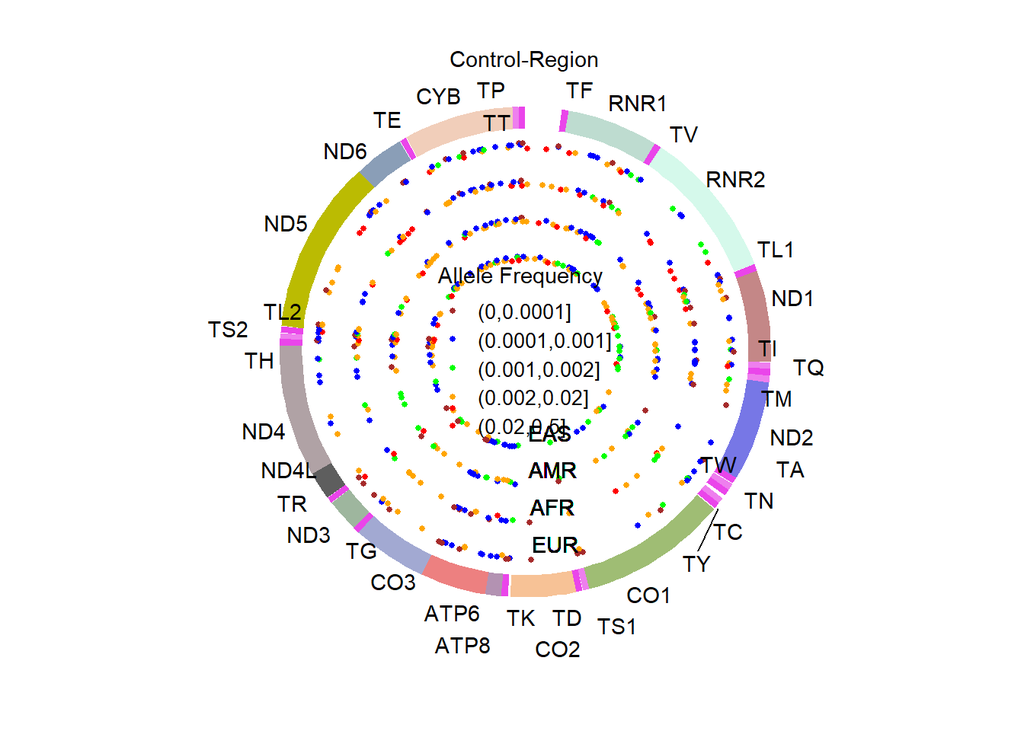

```r
#Allele frequency summary statistics
dat <- all_afreqs %>%
  filter(Subgroup == "All") %>%
  mutate(
    MAF = A1_FREQ,
    `Allele Frequency` = as.character(cut(MAF, c(
      0, 0.0001, 0.001, 0.002, 0.02, .5
    ))),
    `Allele Frequency` = coalesce(`Allele Frequency`, "0"),
    `Allele Frequency` = factor(
      `Allele Frequency`,
      levels = c(
        "0",
        "(0,0.0001]",
        "(0.0001,0.001]",
        "(0.001,0.002]",
        "(0.002,0.02]",
        "(0.02,0.5]"
      )
    ),
    Ancestry = factor(Ancestry, levels = c("EUR", "AFR", "AMR", "EAS"))
  )

# Midpoints in genes, to add labels
midps <- refflat %>%
  group_by(gene) %>%
  summarize(x = round((end - start) / 2 + start), y = -0.5) %>%
  bind_rows(data.frame(gene = "Control-Region", x = 200, y = -0.1)) %>%
  arrange(x)


#Plot solarplot, not including including MAF=0
c_radius <- 10

solarplot_afreq <- dat %>%
  filter(MAF > 0) %>%
  ggplot() +
  ylim(0, c_radius + 1) +
  # AF points
  geom_point(
    aes(
      x = POS,
      y = c_radius - 1.5 * as.numeric(as.factor(Ancestry)) -
        as.numeric(as.factor(`Allele Frequency`)) / 20,
      color = `Allele Frequency`
    ),
    size = 1
  ) +
  # Ancestry track labels
  geom_text(aes(
    x = median(dat$POS) - 300,
    y = c_radius - 1.5 * as.numeric(as.factor(Ancestry)) -
      0.75,
    label = Ancestry
  ),
  hjust = "left") +
  coord_polar(direction = 1) + ##direction = -1) +
  # Gene tracks
  geom_rect(
    data = refflat,
    aes(
      xmin = start,
      xmax = end,
      ymin = c_radius - 1,
      ymax = c_radius - 0.1,
      fill = gene
    ),
    show.legend = F,
    inherit.aes = F
  ) +
  guides(fill = guide_legend(ncol = 2)) +
  guides(color = guide_legend(ncol = 1)) +
  scale_fill_manual(
    values = colours,
    "Genes",
    breaks = names(colours),
    labels = names(colours)
  ) +
  scale_color_manual(
    values = c("gray50", "brown", "blue", "green", "orange", "red"),
    "Allele Frequency",
    breaks = levels(dat$`Allele Frequency`),
    labels = levels(dat$`Allele Frequency`)
  ) +
  xlab("") + ylab("") +
  theme_minimal() +
  theme(
    axis.text = element_blank(),
    axis.ticks.y = element_blank(),
    panel.grid = element_blank(),
    legend.key.size = unit(.5, 'cm'),
    legend.text = element_text(size = 10),
    legend.position = "inside"
  ) +
  geom_text_repel(
    data = midps,
    aes(x = x, y = c_radius, label = gene),
    nudge_y = 0.5,
    min.segment.length = 1.5 ,
    inherit.aes = F
  )

solarplot_afreq
```

```r
ggsave(paste0(image_dir, "solarplot_afreqs_GIA.png"),
       plot = solarplot_afreq,
       w=12, h=10, dpi=400, bg = "white")
```

# Figure 1b - What SNPs / phecodes for the circle plot?

```r
Fig1Helper <- d_sig_fdr %>%
  distinct(Locus, `BP/REF/ALT`, phecode, Ancestry, Subgroup) %>%
  filter(Subgroup != "Non-DM") %>%
  arrange(Locus) %>%
  mutate(popgroup = paste0(Ancestry, Subgroup)) %>%
  select(-c(Ancestry, Subgroup)) %>%
  group_by(Locus, `BP/REF/ALT`, phecode) %>%
  summarize(grps = paste0(popgroup, collapse = ", ")) %>%
  left_join(pheinfo %>% select(phecode, group, description))
#View(Fig1Helper)
```

# Table 3 - UKB replication results

We will also use these for forest plots

```r
ORs <- d_snp_all %>%
  mutate(LCI = signif(L95, 3),
         UCI = signif(U95, 3)) %>%
  select(OR, BETA, LCI, UCI, POS, phecode, Ancestry, Subgroup)
```

```r
# join UKB replication results
MVP_vs_UKB_repl <- UKB_repl %>%
  mutate(Ancestry = "EUR") %>%
  filter(ERRCODE == ".") %>%
  select(
    `BP/REF/ALT`,
    Subgroup,
    Ancestry,
    phecode,
    UKB_trait,
    `UKB # Cases / N (%)`,
    `UKB Alt AF`,
    `UKB P` = P,
    `UKB OR (95% CI)`,
    priority
  ) %>%
  right_join(d_sig_fdr %>% filter(Ancestry == "EUR")) %>%
  ## exclude 244, only report 244.4
  filter(phecode != "244") %>%
  filter(Subgroup != "Non-DM") %>%
  left_join(d_snp_clean) %>%
  left_join(ORs)
# Format the table for output
Table3 <- MVP_vs_UKB_repl %>%
  mutate(
    Replicated = case_when(
      is.na(`UKB Alt AF`) ~ "Not Genotyped",
      is.na(`UKB # Cases / N (%)`) ~ "Phenotype not defined",
      `UKB P` < 0.05 ~ "Yes",
      `UKB P` > 0.05 ~ "No",
      TRUE ~ "--"
    ),
    Annotation = gsub("missense, ", "", Annotation),
    Annotation = ifelse(grepl("MT-RNR", Locus), "rRNA", Annotation),
    Annotation = coalesce(Annotation, "Non-coding"),
    `Description, Phecode` = gsub(" NOS", "", `Description, Phecode`),
    Locus = gsub("MT-", "", Locus),
    `OR (95% CI)` = paste0(signif(OR, 3), " (", signif(LCI, 3), "-", signif(UCI, 3), ")"),
    `UKB P` = signif(`UKB P`, 2),
    UKB_trait = gsub("hypothyroidism_|CHF_|phe_|_mc2", "", UKB_trait),
    UKB_trait = gsub("_", ".", UKB_trait)
  ) %>%
  group_by(Subgroup, POS, phecode) %>%
  arrange(Subgroup, POS, phecode, priority) %>%
  mutate(any_repl = any(Replicated == "Yes")) %>%
  filter(!any_repl | Replicated == "Yes") %>%
  filter((Replicated == "Yes" & row_number() == 1) |
           (Replicated != "Yes" & row_number() == n())) %>%
  ungroup() %>%
  arrange(Subgroup,
          POS, phecode) %>%
  mutate(Subgroup = ifelse(!is.na(lag(Subgroup)) &
                             Subgroup == lag(Subgroup), "", Subgroup)) %>%
  mutate(P = scientific(P, digits = 2)) %>%
  select(
    Subgroup,
    `BP/REF/ALT`,
    Locus,
    Annotation,
    `Description, Phecode`,
    # MVP
    `# Cases / N (%)`,
    `Alt AF`,
    P,
    `OR (95% CI)`,
    # UKB
    starts_with("UKB"),
    Replicated
  ) %>%
  mutate(
    `UKB OR (95% CI)` = ifelse(Replicated == "Not Genotyped",
                               "Not Genotyped", `UKB OR (95% CI)`),
    Replicated = ifelse(Replicated == "Not Genotyped", "--", Replicated)
  ) %>%
  mutate(
    `UKB OR (95% CI)` = ifelse(
      `Description, Phecode` == "Encounter for long-term (current) use of aspirin, 457.3",
      "Phenotype not defined",
      `UKB OR (95% CI)`
    )
  ) %>%
  mutate(UKB_trait = ifelse(`UKB OR (95% CI)` == "Phenotype not defined",
                            "None", UKB_trait)) %>%
  mutate(UKB_trait = gsub("direct", "", UKB_trait))

#Table3 %>% View(.)
```

Add flextable

```r
#reset
init_flextable_defaults()

# Set global defaults
set_flextable_defaults(
  font.size = 8,
  font.family = "Calibri",
  border.color = "black",
  border.style = "solid",
  padding.top = 0,
  padding.bottom = 0,
  padding.left = 1,
  padding.right = 4
)

seps3 <- Table3 %>% mutate(grp = cumsum(Subgroup != "")) %>%
  count(grp) %>% .$n %>% cumsum()

flextable3 <- flextable(Table3 %>%
                          dplyr::rename(Trait = UKB_trait,
                                        AltAF = `UKB Alt AF`)) %>%
  hline(i = seps3,
        border = fp_border(color = "gray")) %>%
  bold(i = which(Table3$Replicated == "Yes")) %>%
  hline(i = nrow(Table3), border = fp_border(width = 2)) %>%
  bold(part = "header")

flextable3 <-
  width(flextable3, width = dim_pretty(flextable3)$widths)
flextable3 <- width(flextable3, j = c(5), width = c(1.5))

#Save flextable to existing doc
tablesdoc <- tablesdoc %>%
  body_add_flextable(flextable3) %>%
  body_end_section_landscape()
```

# SNP-based interaction results (by T2D and Sex)

Create the forest plots

## Figure 2: Forestplot in the manuscript (male vs female)

- significant results in subgroups, and add interaction p-value

```r
#Add all three subgroups for sex
intx_sex_broad <- d_sig_fdr %>%
  filter(Subgroup %in% c("Males", "Females")) %>%
  distinct(POS, phecode, Ancestry) %>%
  left_join(d_snp_all_fmt) %>% # include results that didn't pass filters
  filter(Subgroup %in% c("All", "Males", "Females")) %>%
  left_join(intx_sex %>% distinct(Ancestry, phecode, POS, intx_sex_pval)) %>%
  left_join(ORs) %>%
  # Don't display bars for the ones we didn't include
  mutate(
    OR = ifelse(is.na(fdr_sig), NA, OR),
    LCI = ifelse(is.na(fdr_sig), NA, LCI),
    UCI = ifelse(is.na(fdr_sig), NA, UCI)
  ) %>%
  group_by(POS, phecode, Ancestry) %>%
  # Don't include the ones that are already in the main result
  filter(!(any(Subgroup == "All" & fdr_sig))) %>%
  ungroup()
```

```r
# Data for forestplot
dat_forestplot_sex <- intx_sex_broad %>%
  mutate( intx_pval = intx_sex_pval,
         Population = factor(Subgroup, levels = c("All", "Females", "Males")),
         intx_pval = scientific(intx_pval, digits = 3),
         intx_pval_print = ifelse(`FDR Adjusted P-value` == "-",
                                   "-", as.character(intx_pval)),
         Ancestry = factor(Ancestry, levels = c("EUR", "AFR", "AMR"))
         ) %>%
  group_by(Ancestry, phecode, POS) %>%
  mutate(pval = ifelse(any(intx_pval_print == "-"), "-", intx_pval_print)) %>%
  #Don't repeat certain column values on each row - repetitive
  mutate(across(c( #Ancestry,
                  pval,
                  dbSNP, Locus, `BP/REF/ALT`, `Description, Phecode`,
                 Annotation),
                function(x){ x[2:3] <- ""; return(x) }
         )) %>%
  ## Put phecode on a new line, maintain centering
  # mutate(Ancestry = factor(Ancestry, levels = c("EUR", "AFR"))) %>%
  arrange(Ancestry, POS, phecode) %>%
  mutate(`Description, Phecode` = paste0("\n", gsub(",", ",\n", `Description, Phecode`)),
         Ancestry = as.character(Ancestry),
         Ancestry = ifelse(row_number() == 1, Ancestry, "")
         ) %>%
  ungroup() %>%
  select(Ancestry, `BP/REF/ALT`, dbSNP,
         Gene = Locus,
         Annotation, `Description, Phecode`,
         Population = Subgroup,
         `# Cases / N (%)`, `Alt AF`, `OR (95% CI), P-value`,
         `Adj. P-value` = `FDR Adjusted P-value` ,
         `Int. P-value` = pval, OR, LCI, UCI
         )
```

```r
# data for the horizontal bars
from_rmeta_sex <-
  structure(list(
    mean  = c(NA, dat_forestplot_sex$OR),
    lower = c(NA, dat_forestplot_sex$LCI),
    upper = c(NA, dat_forestplot_sex$UCI)),
    .Names = c("mean", "lower", "upper"),
    row.names = c(NA, -(nrow(dat_forestplot_sex) + 1) ),
    class = "data.frame")

dat_forestplot_sex <- dat_forestplot_sex %>%
  select(-c(OR, LCI, UCI))

tabletext_sex <- rbind(colnames(dat_forestplot_sex),
                       as.matrix(dat_forestplot_sex))
```

Format and create the table/figure

```r
# # lines
thinner_par <- list(NULL, NULL, gpar(col="#444444", lwd = 0.1))
thin_par <- list(NULL, NULL, gpar(col="#444444"))
thick_par <- list(NULL, NULL, gpar(col="#444444", lwd = 4))

hlines_sex <- c(
  list(NULL, #top border
       gpar(col="#444444", lwd = 4)), #border under column names
  rep(thin_par, 6), # EUR - inside borders
  thick_par, #thick border between EUR and AFR
  rep(thin_par, 8), # AFR - inside borders
  thick_par,
  rep(thin_par, 2), # AMR - inside borders
  list(NULL, #last 2 entries
       NULL, #last 2 entries
       gpar(col="#444444", lwd = 4)) #bottom border
)

fpt_sex <- forestplot(labeltext = tabletext_sex,
           from_rmeta_sex,
           is.summary= c(T, rep(F, nrow(tabletext_sex)-1)),
           align = c(rep("l", ncol(tabletext_sex)-2), "r", "r"),
           hrzl_lines = hlines_sex,
           xlog = T, xlab = "OR", xticks.digits = 1,
           new_page = T,
           graph.pos = 8, boxsize = 0.3, lwd.ci = 3,
           col = fpColors(box="royalblue",line="darkblue"),
           colgap = unit(.05, "npc"),
           txt_gp = fpTxtGp(cex = 2,
                            ticks = gpar(cex = 1.8),
                            xlab = gpar(cex = 1.8),
                            label = list(gpar(fontface = "bold"))),

           line.margin = 0.3)

# Save image as png
png(paste0(image_dir, "Forestplot_by_sex.png"),
     width = 45,
     height = 25,
     units = 'in',
     res = 300)

fpt_sex

dev.off()
```

Also need this as pdf for final submission to Nature Comms; make some tweaks to get it to fit within required dimensions

```r
tabletext_sex_pdf <- tabletext_sex
tabletext_sex_pdf[,"Gene"] <- gsub("MT-", "", tabletext_sex_pdf[,"Gene"])
##tabletext_sex_pdf <- tabletext_sex_pdf[,-3]
tabletext_sex_pdf[,"Annotation"] <-
  gsub("missense, ", "\nmissense,\n", tabletext_sex_pdf[,"Annotation"])
tabletext_sex_pdf[,"Annotation"] <-
  gsub("start_lost, ", "\nstart_lost,\n", tabletext_sex_pdf[,"Annotation"])
tabletext_sex_pdf[,"Description, Phecode"] <-
  gsub("\nIntestinal disaccharidase deficiencies and disaccharide malabsorption,\n 271.3",
       "\nIntestinal disaccharidase deficiencies and\ndisaccharide malabsorption, 271.3",
       tabletext_sex_pdf[,"Description, Phecode"])

tabletext_sex_pdf[,"Description, Phecode"] <-
  gsub("\nDisorders of carbohydrate transport and metabolism,\n 271",
       "\nDisorders of carbohydrate transport and\nmetabolism, 271",
       tabletext_sex_pdf[,"Description, Phecode"])

tabletext_sex_pdf[1, colnames(tabletext_sex_pdf) == "Adj. P-value"] <- "Adj. P"
tabletext_sex_pdf[1, colnames(tabletext_sex_pdf) == "Int. P-value"] <- "Int. P"
tabletext_sex_pdf[1, colnames(tabletext_sex_pdf) == "BP/REF/ALT"] <- "BP/Ref/Alt"

hlines_sex_pdf <- c(
  list(NULL, #top border
       gpar(col="#444444", lwd = 1.5)), #border under column names
  rep(thinner_par, 6), # EUR - inside borders
  thin_par, #thick border between EUR and AFR
  rep(thinner_par, 8), # AFR - inside borders
  thin_par,
  rep(thinner_par, 2), # AMR - inside borders
  list(NULL, #last 2 entries
       NULL, #last 2 entries
       gpar(col="#444444", lwd = 1.5)) #bottom border
)

txtgp <- 0.9
fpt_sex_pdf <- forestplot(labeltext = tabletext_sex_pdf,
           from_rmeta_sex,
           is.summary= c(T, rep(F, nrow(tabletext_sex_pdf)-1)),
           align = c(rep("l", ncol(tabletext_sex_pdf)-2), "r", "r"),
           hrzl_lines = hlines_sex_pdf,
           xlog = T, xlab = "OR", xticks.digits = 1,
           new_page = T,
           graph.pos = 8,
           boxsize = 0.4, lwd.ci = 1,
           col = fpColors(box="royalblue",line="darkblue"),
           colgap = unit(.01, "npc"),
           txt_gp = fpTxtGp(
             cex = txtgp,
             ticks = gpar(cex = txtgp),
             xlab = gpar(cex = txtgp),
             #label = list(gpar(fontface = "bold")),
             summary = list(gpar(fontface = "bold"))
             ),
           line.margin = 0.3,
           graphwidth = unit(1, 'in'))

pdf(paste0(image_dir, "Forestplot_by_sex.pdf"),
     width = 8.2,
    height = 6,
     pointsize = 1,
    family = "Helvetica",
    colormodel = "srgb"
    )

fpt_sex_pdf

dev.off()
```

## Figure 3: Forestplot in the manuscript (T2D vs non-diabetes)

- Anything significant in T2D-only
- all interaction tests whether significant or not
- we chose not to discuss those significant in non-DM only

```r
# Add all three subgroups for sex
intx_t2d_broad <- d_sig_fdr %>%
  filter(Subgroup == "T2D") %>%
  distinct(POS, phecode, Ancestry) %>%
  left_join(d_snp_all_fmt) %>% # include results that didn't pass filters
  filter(Subgroup %in% c("All", "T2D", "Non-DM")) %>%
  left_join(intx_t2d %>% distinct(Ancestry, phecode, POS, intx_t2d_pval)) %>%
  left_join(ORs) %>%
  # Don't display bars for the ones we didn't include
  mutate(
    OR = ifelse(is.na(fdr_sig), NA, OR),
    LCI = ifelse(is.na(fdr_sig), NA, LCI),
    UCI = ifelse(is.na(fdr_sig), NA, UCI)
  ) %>%
  group_by(POS, phecode, Ancestry) %>%
  # Don't include the ones that are already in the main result
  filter(!(any(Subgroup == "All" & fdr_sig))) %>%
  ungroup()
```

```r
# Data for forestplot
dat_forestplot_t2d <- intx_t2d_broad %>%
  mutate(
    intx_pval = intx_t2d_pval,
    Population = factor(
      Subgroup,
      levels = c("All", "T2D", "Non-DM"),
      labels = c("All", "T2D", "Non DM")
    ),
    intx_pval = scientific(intx_pval, digits = 3),
    intx_pval_print = ifelse(`FDR Adjusted P-value` == "-",
                             "-", as.character(intx_pval)),
    Ancestry = factor(Ancestry, levels = c("EUR", "AFR", "AMR"))
  ) %>%
  group_by(Ancestry, phecode, POS) %>%
  arrange(Ancestry, POS, phecode) %>%
  mutate(pval = ifelse(any(intx_pval_print == "-"), "-", intx_pval_print)) %>%
  #Don't repeat certain column values on each row - repetitive
  mutate(across(c( pval,
                  dbSNP, Locus, `BP/REF/ALT`, `Description, Phecode`,
                 Annotation),
                function(x){ x[2:3] <- ""; return(x) }
         )) %>%
  ## Put phecode on a new line, maintain centering
  mutate(
    `Description, Phecode` = paste0("\n", gsub(",", ",\n", `Description, Phecode`)),
    #Ancestry = factor(Ancestry, levels = c("EUR", "AFR"))
    Ancestry = as.character(Ancestry),
    Ancestry = ifelse(row_number() == 1, Ancestry, "")
  ) %>%
  ungroup() %>%
  select(
    Ancestry,
    `BP/REF/ALT`,
    dbSNP,
    Gene = Locus,
    Annotation,
    `Description, Phecode`,
    Population = Subgroup,
    `# Cases / N (%)`,
    `Alt AF`,
    `OR (95% CI), P-value`,
    `Adj. P-value` = `FDR Adjusted P-value`,
    `Int. P-value` = pval,
    OR,
    LCI,
    UCI
  )

# data for the horizontal bars
from_rmeta_t2d <-
  structure(list(
    mean  = c(NA, dat_forestplot_t2d$OR),
    lower = c(NA, dat_forestplot_t2d$LCI),
    upper = c(NA, dat_forestplot_t2d$UCI)),
    .Names = c("mean", "lower", "upper"),
    row.names = c(NA, -(nrow(dat_forestplot_t2d) + 1) ),
    class = "data.frame")

dat_forestplot_t2d <- dat_forestplot_t2d %>%
  select(-c(OR, LCI, UCI))

# data for text to display
tabletext_t2d <- rbind(colnames(dat_forestplot_t2d),
                       as.matrix(dat_forestplot_t2d))
```

Format and save the plot

```r
# Not including NDM
hlines_t2d <- c(
  list(NULL, #top border
       gpar(col="#444444", lwd = 4)), #border under column names
  thick_par,
  thick_par,
  thick_par,
  thick_par #bottom border
)

fpt_t2d <- forestplot(tabletext_t2d,
           from_rmeta_t2d,
           is.summary= c(T, rep(F, nrow(tabletext_t2d)-1)),
           align = c(rep("l", ncol(tabletext_t2d)-2), "r", "r"),
           hrzl_lines = hlines_t2d,
           xlog = T, xlab = "OR", xticks.digits = 1,
           new_page = T,
           graph.pos = 8, boxsize = 0.3, lwd.ci = 3,
           col = fpColors(box="royalblue",line="darkblue"),
           colgap = unit(.05, "npc"),
           txt_gp = fpTxtGp(cex = 2,
                            ticks = gpar(cex = 1.8),
                            xlab = gpar(cex = 1.8),
                            label = list(gpar(fontface = "bold"))),

           line.margin = 0.3)

# Save as png
png(paste0(image_dir, "Forestplot_by_t2d.png"),
     width = 45,
     height = 12,
     units = 'in',
     res = 300)

fpt_t2d

dev.off()
```

Also need this as pdf for final submission to Nature Comms

```r
tabletext_t2d_pdf <- tabletext_t2d
tabletext_t2d_pdf[,"Gene"] <- gsub("MT-", "", tabletext_t2d_pdf[,"Gene"])
##tabletext_t2d_pdf <- tabletext_t2d_pdf[,-3]
tabletext_t2d_pdf[,"Annotation"] <-
  gsub("missense, ", "\nmissense,\n", tabletext_t2d_pdf[,"Annotation"])
tabletext_t2d_pdf[,"Annotation"] <-
  gsub("start_lost, ", "\nstart_lost,\n", tabletext_t2d_pdf[,"Annotation"])
tabletext_t2d_pdf[,"Description, Phecode"] <-
  gsub("\nDisorders of the pituitary gland and its hypothalamic control,\n 253",
       "\nDisorders of the pituitary gland and\nits hypothalamic control, 253",
       tabletext_t2d_pdf[,"Description, Phecode"])


tabletext_t2d_pdf[1, colnames(tabletext_t2d_pdf) == "Adj. P-value"] <- "Adj. P"
tabletext_t2d_pdf[1, colnames(tabletext_t2d_pdf) == "Int. P-value"] <- "Int. P"
tabletext_t2d_pdf[1, colnames(tabletext_t2d_pdf) == "BP/REF/ALT"] <- "BP/Ref/Alt"

hlines_t2d_pdf <- c(
  list(NULL, #top border
       gpar(col="#444444", lwd = 1.5)), #border under column names
  thin_par,
  thin_par,
  thin_par,
  list(NULL, #last 2 entries
       NULL, #last 2 entries
       gpar(col="#444444", lwd = 1.5)) #bottom border
)

# Adjust text size
txtgp <- 0.9

fpt_t2d_pdf <- forestplot(labeltext = tabletext_t2d_pdf,
           from_rmeta_t2d,
           is.summary= c(T, rep(F, nrow(tabletext_t2d_pdf)-1)),
           align = c(rep("l", ncol(tabletext_t2d_pdf)-2), "r", "r"),
           hrzl_lines = hlines_t2d_pdf,
           xlog = T, xlab = "OR", xticks.digits = 1,
           new_page = T,
           graph.pos = 8,
           boxsize = 0.4, lwd.ci = 1,
           col = fpColors(box="royalblue",line="darkblue"),
           colgap = unit(.01, "npc"),
           txt_gp = fpTxtGp(
             cex = txtgp,
             ticks = gpar(cex = txtgp),
             xlab = gpar(cex = txtgp),
             #label = list(gpar(fontface = "bold")),
             summary = list(gpar(fontface = "bold"))
             ),
           line.margin = 0.3,
           graphwidth = unit(1, 'in'))

# Save to pdf
pdf(paste0(image_dir, "Forestplot_by_t2d.pdf"),
     width = 8.2,
     #height = 7.2,
    height = 2,
     pointsize = 1,
    family = "Helvetica",
    colormodel = "srgb"
    )

fpt_t2d_pdf

dev.off()
```

# Gene-based results (phecodes and biomarkers)

Filter results

```r
fdr = 0.05

d_gene_clean <- d_gene_all %>%
  filter(observations >= 500 &
           (n_cases >= 500 | is.na(n_cases))) %>%
  filter(n_ctrls >= 500 | is.na(n_ctrls)) %>%
  select(-n_ctrls) %>%
  group_by(Ancestry, Subgroup) %>%
  mutate(P.value.adj.fdr = p.adjust(P.value, "BH"))
```

```r
d_gene_clean %>%
  distinct(trait, SetID, Ancestry, Subgroup) %>%
  nrow()
```

```
## [1] 44646
```

### Significant gene-based results (FDR)

```r
gene_sig_fdr <- d_gene_clean  %>%
  filter(P.value.adj.fdr <= fdr)
```

```r
# BP ranges for non-TRNA genesets
bprange <- refflat %>%
  filter(!grepl("^T", gene)) %>%
  # this is on 1-based scale
  mutate(BP = paste0( start, "-", end)) %>%
  mutate(SetID = paste0("MT-", gene)) %>%
  dplyr::select(-gene, -start, -end)
```

### Table 4 - significant gene-based results

Write out MT-gene significant results suitable for table 4.

```r
table4 <- gene_sig_fdr %>%
  left_join(bprange) %>%
  mutate(
    Symbol = gsub("MT-", "", SetID),
    #Ancestry = gsub("_GIA", "", RACE),
    Gene = gsub("MT-", "", SetID),
    bpstart = as.numeric(gsub("-.*", "", BP)),
    Population = Subgroup,
    `# Cases / N (%)` =
      ifelse(
        n_cases < 500,
        " < 500",
        paste(
          formatC(n_cases, format = "d", big.mark = ","),
          "/",
          formatC(observations,
                  format = "d", big.mark = ","),
          paste0("(", round(prop_cases * 100, 1), "%)"),
          sep = " "
        )
      ),
    Trait = coalesce(biomarker_key[trait], phecode),
    P = scientific(P.value, digits = 3),
    P.value.adj.fdr = scientific(P.value.adj.fdr, digits = 3)
  ) %>%
  left_join(pheinfo) %>%
  ungroup() %>%
  mutate(Ancestry = factor(
    Ancestry,
    levels = c("EUR", "AFR", "AMR", "EAS"),
    labels = c("EUR", "AFR", "AMR", "EAS")
  )) %>%
  dplyr::select(Population, Ancestry, BP, Gene, `# Markers` = N.Marker.Test,
         `# Cases / N (%)`, Trait, description, Chapter = group, bpstart,
         `P-value` = P, `Adj. P-value` = P.value.adj.fdr) %>%
  arrange(Population, Ancestry, bpstart, `P-value`) %>%
  dplyr::select(-bpstart)
```

Make the flextable and add it to the existing object

```r
#reset
init_flextable_defaults()

# Set global defaults
set_flextable_defaults(
  font.size = 8,
  font.family = "Calibri",
  border.color = "black",
  border.style = "solid",
  padding.top = 0,
  padding.bottom = 0,
  padding.left = 2,
  padding.right = 2
)

table4 <- table4 %>%
  ungroup() %>%
  mutate(grp1 = cumsum(coalesce(Population != lag(Population) |
                                Ancestry != lag(Ancestry), FALSE)))

flextable4 <- flextable(table4 %>%
                          select(-grp1) %>%
                          mutate(`# Markers` = as.character(`# Markers`))
                        ) %>%
                       autofit() %>%
                       hline(i = table4 %>% count(grp1) %>% .$n %>% cumsum(),
                             border = fp_border(color="gray")) %>%
                       hline(i = table4 %>% count(Population) %>% .$n %>% cumsum(),
                             border = fp_border(width = 1.5)) %>%
  bold(part = "header")

tablesdoc <- tablesdoc %>%
  body_add_flextable(flextable4) %>%
  body_end_section_landscape()
```

### What Loci are significant in both SNP- and gene-based analyses?

```r
cond_anly <-
  d_sig_fdr %>% distinct(POS, Locus, phecode, Ancestry, Subgroup) %>%
  inner_join(
    gene_sig_fdr %>%
      ungroup() %>%
      distinct(Locus = SetID, phecode, Ancestry, Subgroup, description, P.value)
  )
cond_anly
```

```
##      POS   Locus phecode Ancestry Subgroup                    description
##    <int>  <char>  <char>   <char>   <char>                         <char>
## 1:  1694 MT-RNR2     252      AFR  Females Disorders of parathyroid gland
## 2:  1694 MT-RNR2   276.5      AFR  Females                    Hypovolemia
## 3:  1243 MT-RNR1   253.2      EUR      T2D         Pituitary hypofunction
## 4:  3505  MT-ND1   253.2      EUR      T2D         Pituitary hypofunction
## 5:  9804  MT-CO3  250.42      EUR  Females         Other abnormal glucose
##         P.value
##           <num>
## 1: 8.162180e-06
## 2: 1.084744e-06
## 3: 1.052826e-05
## 4: 7.815231e-06
## 5: 3.248040e-05
```

Combining SNP- and gene-based

```r
# d_sig_fdr %>% distinct(Locus, phecode) %>%
#   bind_rows(gene_sig_fdr %>% ungroup() %>%
#               distinct(Locus = SetID, phecode)) %>%
#   arrange(Locus) %>%
#   left_join(pheinfo %>% select(phecode, description))
```

# Supplementary Figure 1 - Flowchart

```r
# flowchart
flowchart <- DiagrammeR::grViz(paste0("
                  digraph flowchart {
                  graph [layout = dot, rankdir = TB]

                  node [shape = box, style = filled, fillcolor = white, margin=0.3]

                  A [label = '", flowchart_data$text[1], "']
                  B [label = '", flowchart_data$text[2], "']
                  C [label = '", flowchart_data$text[3], "']
                  D [label = '", flowchart_data$text[4], "']
                  E [label = '", flowchart_data$text[5], "']
                  F [label = '", flowchart_data$text[6], "']
                  G [label = '", flowchart_data$text[7], "']
                  H [label = '", flowchart_data$text[8], "']
                  I [label = '", flowchart_data$text[9], "']
                  J [label = '", flowchart_data$text[10], "']

                  A -> B -> C -> D -> E -> F
                  F -> G
                  F -> H
                  F -> I
                  F -> J
                  }
                  "))
flowchart
```

[interactive chart not shown]

Export flowchart to png

```r
svg <- export_svg(flowchart)
rsvg_png(
  charToRaw(svg),
  file = paste0(image_dir, "flowchart.png"),
  width = 96 * 7,
  height = 96 * 10
)
```

# Supplementary Figure 12 (Solar plot for genebased analysis)

Input data setup

```r
# Length of genes
refflat_length <- refflat %>%
  dplyr::rename(Gene = gene) %>%
  # Add +  1 to length now that we added + 1 to start
  mutate(
    gene_length = end - start + 1,
    # Helps when labelling genes
    small_gene = ifelse(gene_length < 350, 1, 0),
    # Rotation/angle for gene name on circlular plot
    pos.rt = 360 - ((start + gene_length / 2) / (16023)) * 360
  )

# Good automatic labels was difficult, so manually specify positions
refflat_length_small_plothelp <- refflat_length %>%
  filter(small_gene == 1) %>%
  mutate(plot_pos = case_when(
    Gene %in% c("TF", "TM", "TC", "TD", "ATP8", "TL2") ~ start + gene_length/2 + 60,
    Gene %in% c("TI", "TA", "TH", "TT")  ~ start + gene_length/2 - 60,
    Gene %in% c("TY")  ~ start + gene_length/2 + 120,
    Gene %in% c("TW")  ~ start + gene_length/2 - 120,
    TRUE ~ start + gene_length/2)
  )

dat_plot_solargene <- d_gene_clean %>%
  mutate(neglogp = -log10(P.value)) %>%
  left_join(gene_sig_fdr %>% mutate(sig=1)) %>%
  mutate(sig = coalesce(sig, 0)) %>%
  dplyr::rename(Gene = SetID) %>%
  mutate(Gene = gsub("MT-", "", Gene)) %>%
  left_join(refflat_length) %>%
  arrange(Gene, as.numeric(phecode)) %>%
  group_by(Gene) %>%
  mutate(
    length_nrow_ratio = dplyr::n() / gene_length,
    phe_pos = row_number() / length_nrow_ratio,
    POS = phe_pos + start
  ) %>%
  ungroup() %>%
  mutate(
    group = ifelse(is.na(group) | group == "", "biomarkers", group),
    Ancestry = factor(Ancestry, levels  = c("EUR", "AFR", "AMR", "EAS")),
    gene_lbl = ifelse(sig, Gene, NA),
    lbl_genesubgroup = ifelse(sig, paste0("(", gene_lbl, ", ", Subgroup, ")"), NA),
    description = coalesce(biomarker_key[trait], description),
    description_shortened = gsub("[;,]* and ", "/", description),
    phecode_title = paste0(phecode, "-", description_shortened),
    lbl = ifelse(sig, coalesce(biomarker_key[trait], phecode_title), ""),
    #Add the gene AND population label for all points.
    lbl = ifelse(sig, paste0(lbl, "\n", lbl_genesubgroup), NA),
    points_nonsig = ifelse(sig, NA, POS),
    #NONsignificant points
    points_sig = ifelse(sig, POS, NA) #, #significant points
  )
```

[output not shown]

```r
# Define gray and white colors for gene bands
colours_gw <- colours
colours_gw[1:length(colours_gw)] <- rep(c("gray50", "gray60", "gray70"), 100)[1:length(colours)]

# Define colours for phecode group key
colours_group <-
  lapply(c("purple1", "aquamarine4", "darkorange3", "deeppink2"),
         lighten_col) %>% unlist()

names(colours_group) <-
  c("circulatory system",
    "endocrine/metabolic",
    "digestive",
    "biomarkers")

#scales::show_col(colours_group)
```

Plot

```r
# ggrepel has some randomness so set seed
set.seed(12345)

c_radius <- 6.5

fplot <- ggplot(dat_plot_solargene) +
  ylim(0, max(dat_plot_solargene$neglogp) + c_radius + 1) +
  coord_polar(direction = -1, clip = "off") +
  # Add Concentric lines
  geom_hline(
    yintercept = c_radius + 1:10,
    color = "gray",
    linewidth = 0.1
  ) +
  # Gene bands
  geom_rect(
    data = refflat,
    aes(
      xmin = start,
      xmax = end,
      ymin = c_radius - 1.2,
      ymax = c_radius - 0.2,
      fill = gene
    ),
    inherit.aes = F,
    show.legend = F
  ) +
  # Gene labels on the band (for larger genes)
  geom_textpath(
    data = refflat_length,
    aes(
      x = start + gene_length / 2,
      y = c_radius - 0.7,
      label = ifelse(small_gene, NA, Gene),
      angle = ifelse(small_gene, 90, 0),
      size = ifelse(small_gene, 1.5, 5)
    ),
    inherit.aes = F,
    show.legend = F
  ) +
  # Plot non-significant points (by phecode group)
  geom_point(aes(
    x = points_nonsig,
    y = neglogp + c_radius,
    shape = Ancestry,
    color = group
  ),
  size = 1) +
  # Plot significant points - larger point size
  geom_point(aes(
    x = points_sig,
    y = neglogp + c_radius,
    shape = Ancestry,
    color = group
  ),
  size = 3.5) +
  # Label significant points
  geom_text_repel(
    aes(
      x = POS,
      y = neglogp + c_radius,
      label = lbl
    ),
    show.legend = F,
    max.overlaps = Inf,
    max.time = 40,
    color = "gray1",
    size = 3,
    box.padding = unit(1, "lines"),
    nudge_x = -.2,
    nudge_y = 0.2
  ) +
  # Label small genes that don't fit well in the bands
  geom_text(
    data = refflat_length_small_plothelp,
    aes(
      x = plot_pos,
      y = c_radius + .25,
      angle = 90 - ifelse(pos.rt >= 180, pos.rt - 180, pos.rt),
      label = Gene
    ),
    inherit.aes = F,
    size = 3,
    show.legend = F
  ) +
  # Color scheme for points
  scale_colour_manual(values = colours_group, "Phecode Type") +
  # Color scheme for genes (grays)
  scale_fill_manual(values = colours_gw, "", breaks = names(colours_gw)) +
  # Plot details
  guides(fill = "none", size = "none") +
  xlab("") + ylab("") +
  theme_minimal() +
  theme(
    axis.text = element_blank(),
    axis.ticks.y = element_blank(),
    legend.position = c(0.53, 0.49),
    legend.key.size = unit(0.4, 'cm'),
    panel.grid = element_blank()
  ) +
  # Shape scheme for ancestries
  scale_shape_manual(values = c(15, 16, 17, 9)) +
  # Size for gene labels?
  scale_size(range = c(2, 3.5)) # finicky

# save to png
ggsave(
  paste0(image_dir, "combined_fdr_solarplot_genebased.png"),
  plot = fplot,
  w = 12,
  h = 10,
  dpi = 400,
  bg = "white"
)
```

# Supplementary Figure 8 - compare with gnomAD

### Pull the data from gnoMAD

Only need to run this once.

```r
# # 1. gnomAD API URL
# url <- "https://gnomad.broadinstitute.org/api"
#
# dataset <- "gnomad_r4"
#
# # 2. get list of gnoMAD mitochondrial variants overlapping with MVP's
# query_list <- paste0('
# {
#   region(chrom:"M", start:1, stop:20000, reference_genome: GRCh38) {
#     mitochondrial_variants(dataset: ', dataset, ') {
#       variant_id
#     }
#   }
# }')
#
# resp <- POST(url, body = list(query = query_list), encode = "json")
# json <- content(resp, as = "text")
# parsed <- fromJSON(json, flatten = TRUE)
#
# variant_ids <- parsed$data$region$mitochondrial_variants$variant_id
# current_variant_ids_df <- data.frame("gnomadID" = variant_ids) %>%
#   separate_wider_delim(gnomadID, delim = "-",
#                        names = c(NA, "POS", "REF_gnomad", "ALT_gnomad"),
#                        cols_remove = FALSE) %>%
#   mutate(POS = as.numeric(POS)) %>%
#   # join by POS
#   inner_join(all_afreqs %>% distinct(POS, ID, REF, ALT)) %>%
#   # Ref and Alt must be the same 2 alleles, but they can be switched
#   filter( (REF == REF_gnomad | REF == ALT_gnomad)  &
#           (ALT == REF_gnomad | ALT == ALT_gnomad) )
# nrow(current_variant_ids_df) # 217
#
# # how many have ref/alt switched?
# current_variant_ids_df %>%
#   count(REF == REF_gnomad,
#         ALT == ALT_gnomad) #3
#
# # # View them
# # current_variant_ids_df %>%
# #   filter(REF != REF_gnomad) %>%
# #   left_join(all_afreqs %>% filter(Subgroup == "All"))
# # # For these, gnomad reports freqs for major alleles
#
# # Variant ids to query
# current_variant_ids <- current_variant_ids_df$gnomadID
#
# # 3. loop through variants to get detailed info about ACs in each ancestry
# all_data <- list()
#
# # Pull the allele number (an), homoplasmic allele count (ac_hom), and heteroplasmic ac (ac_het)
# # For each ancestry/population (id)
# # Limit of 10 queries per 60 seconds; sleep 8s in between each to give a good buffer
# # Query will take around 30 minutes
# for(vid in current_variant_ids[33:217]){
#   query_detail <- paste0('
#   {
#     mitochondrial_variant(dataset: ', dataset, ', variant_id: "', vid, '") {
#       variant_id
#       max_heteroplasmy
#       rsid
#       haplogroup_defining
#       populations {
#         id
#         an
#         ac_het
#         ac_hom
#       }
#     }
#   }')
#   print(paste0("Querying SNP ", match(vid, current_variant_ids),
#                " of ", length(current_variant_ids)))
#   start_time <- Sys.time()
#   resp2 <- POST(url, body = list(query = query_detail), encode = "json")
#   json2 <- content(resp2, as = "text")
#   parsed2 <- fromJSON(json2, flatten = TRUE)
#   all_data[[vid]] <- parsed2$data$mitochondrial_variant
#   elapsed <- as.numeric(difftime(Sys.time(), start_time, units = "secs"))
#   wait <- 10 - elapsed
#   if (wait > 0){
#     Sys.sleep(wait)
#   }
# }
#
# # 4. flatten to CSV
# records <- lapply(all_data, function(v){
#   base <- tibble(
#     variant_id = v$variant_id,
#     max_heteroplasmy = v$max_heteroplasmy,
#     rsid = v$rsid,
#     haplogroup_defining = v$haplogroup_defining
#   )
#
#   pops <- as_tibble(v$populations)
#   if(nrow(pops) == 0){
#     base
#   } else {
#     tidyr::crossing(base, pops)
#   }
# })
#
# # Calculate allele frequencies, filter to populations of interest
# # Population mappings: https://www.clinpgx.org/page/populationMappings
# # EUR -> NFE (Non-Finnish Europeans) AND FIN (Finnish)?
# # For simplicity, we'll just use NFE.
# # We also
# gnomad_afs <- bind_rows(records) %>%
#   mutate(af_het = ac_het/an,
#          af_hom = ac_hom/an,
#          af_total = (ac_het + ac_hom)/an) %>%
#   # Keep all just in case we want to use FIN
#   rename(gnomadID = variant_id) %>%
#   left_join(current_variant_ids_df) %>%
#   arrange(POS)
#
# # 5. Write out query results
# ## previous version was v 3.1.2
# #fwrite(gnomad_afs, paste0(output_dir, "gnomad_mitochondrial_variants_details_v4.1.txt"))
```

```r
# # check that they were all retrieved
# unique(current_variant_ids) %>% length()
# gnomad_afs %>% distinct(gnomadID) %>% nrow()
# missing_gnomad_ids <- setdiff(current_variant_ids, unique(gnomad_afs$gnomadID))
# missing_gnomad_ids
```

### Reformat the gnoMAD data

```r
# Subtract AF from 1 if need to switch REF/ALT.
gnomad_afs_long <-
  fread(paste0(
    output_dir,
    "gnomad_mitochondrial_variants_details_v4.1.txt"
  )) %>%
  mutate(
    af_hom = ifelse(REF_gnomad == ALT, 1 - af_hom, af_hom),
    af_het = ifelse(REF_gnomad == ALT, 1 - af_het, af_het),
    af_total = ifelse(REF_gnomad == ALT, 1 - af_total, af_total),
    Ancestry = toupper(id)
  ) %>%
  filter(Ancestry %in% c("NFE", "AFR", "AMR", "EAS")) %>%
  mutate(Ancestry = ifelse(Ancestry == "NFE", "EUR", Ancestry)) %>%
  select(-contains(c("REF", "ALT")))

# Get wide format
gnomad_afs_wide <- gnomad_afs_long  %>%
  select(POS, ID, rsid, gnomadID, af_het, af_hom, af_total, Ancestry) %>%
  pivot_wider(names_from = Ancestry,
              values_from = c(af_hom, af_het, af_total)) %>%
  select(POS, ID, rsid, gnomadID, contains(c("EUR", "AFR", "AMR", "EAS")))
```

Also format the MVP allele frequencies

```r
# MVP Use version contains all the filtered out snps
mvp_afs_long <- all_afreqs %>%
  filter(Subgroup == "All")
mvp_afs_wide <- mvp_afs_long %>%
  distinct(Ancestry, ID, POS, REF, ALT, ALT_FREQ) %>%
  pivot_wider(names_from = Ancestry, values_from = "ALT_FREQ") %>%
  select(ID, BP = POS, REF, ALT, contains(c("EUR", "AFR", "AMR", "EAS")))
```

Combine and compare gnoMAD and MVP frequencies

```r
gnomAD_sum_wide <- left_join(mvp_afs_wide, gnomad_afs_wide)
```

```r
# For plots
gnomAD_sum_long <- full_join(mvp_afs_long, gnomad_afs_long)
# Format and compare on log scale
dat_compare <- gnomAD_sum_long %>%
  select(ID, gnomadID, POS, id, Ancestry, ALT_FREQ,
         af_hom, `Allele Count (gnomAD)` = ac_hom) %>%
  # since we will compare them on log scale, they must both have non-zero frequency
  filter(af_hom > 0 & ALT_FREQ > 0 & ALT_FREQ < 1) %>%
  # Use minor allele frequency in MVP
  mutate(
    MAF_mvp = pmin(ALT_FREQ, 1 - ALT_FREQ),
    # Make gnomad consistent - could be above 50% rarely
    AF_gnomad = case_when(ALT_FREQ == MAF_mvp ~ af_hom,
                          TRUE ~ 1 - af_hom),
    # -log10 versions
    MVP = -log10(MAF_mvp),
    gnomAD = -log10(AF_gnomad),
  ) %>%
  filter(!is.na(gnomAD)) %>%
  mutate(BP = paste0("MT", POS))
```

### Generate plots

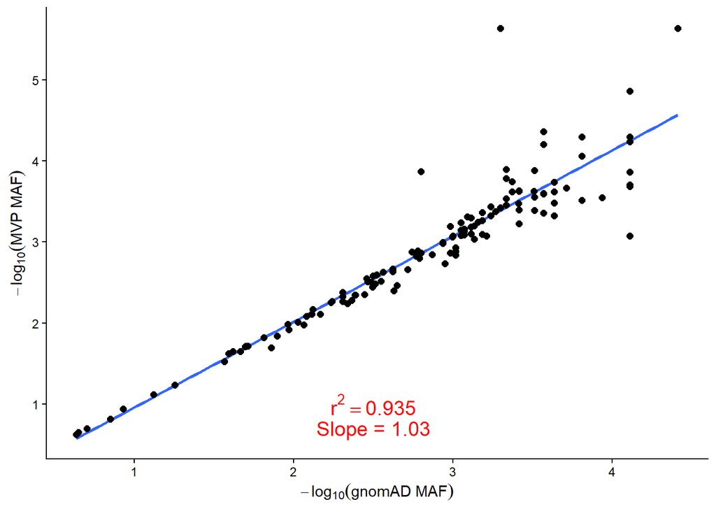

```r
xpos <- 2.5
ypos <- c(1, .7)

# function to add the r2 and slope to plots
add_anno <- function(x) {
  x + annotate(geom = "text", x = xpos, y = ypos[1],
           #label = bquote(r^2 == .(rr)),
           label = paste0("r^2 == ", rr), parse = TRUE,
           color="red", size = 5) +
      annotate(geom = "text", x = xpos, y = ypos[2],
           label = paste0("Slope = ", slope),
           color= "red", size = 5)
}

# EUR
dat <- dat_compare %>% filter(Ancestry == "EUR")
rr = signif(cor(dat$gnomAD, dat$MVP, use = "pairwise.complete.obs"), 3)
tm.lm = summary(lm(MVP ~ -1 + gnomAD, data = dat))
slope = signif(tm.lm$coefficients[1,1], 3)

ggp <- ggplot(dat, aes(x = gnomAD, y = MVP)) +
  stat_smooth(
    method = "lm",
    formula = y ~ x,
    geom = "smooth",
    se = FALSE
  ) +
  geom_point(size = 2) +
  xlab(expression(-log[10](paste("gnomAD MAF")))) +
  ylab(expression(-log[10](paste("MVP MAF")))) +
  theme_classic()
ggp_EUR <- add_anno(ggp)


# AFR
dat <- dat_compare %>% filter(Ancestry == "AFR")
rr = signif(cor(dat$gnomAD, dat$MVP, use = "pairwise.complete.obs"), 3)
tm.lm = summary(lm(MVP ~ -1 + gnomAD, data = dat))
slope = formatC(tm.lm$coefficients[1,1], format = "f", 2)
ggp_AFR <- ggp %+% (dat) %>% add_anno(.)


# AMR
dat <- dat_compare %>% filter(Ancestry == "AMR")
rr = signif(cor(dat$gnomAD, dat$MVP, use = "pairwise.complete.obs"), 3)
tm.lm = summary(lm(MVP ~ -1 + gnomAD, data = dat))
slope = signif(tm.lm$coefficients[1,1], 3)
ggp_AMR <- ggp %+% (dat) %>% add_anno(.)


# EAS
dat <- dat_compare %>% filter(Ancestry == "EAS")
rr = signif(cor(dat$gnomAD, dat$MVP, use = "pairwise.complete.obs"), 3)
tm.lm = summary(lm(MVP ~ -1 + gnomAD, data = dat))
slope = signif(tm.lm$coefficients[1,1], 3)
ggp_EAS <- ggp %+% (dat) %>% add_anno(.)


# display
ggp_EUR
```

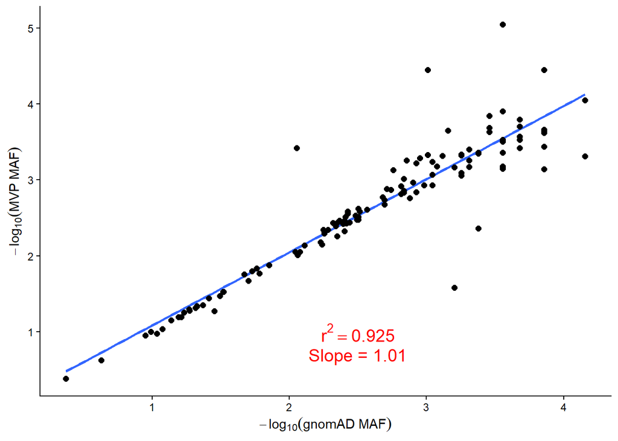

```r
ggp_AFR
```

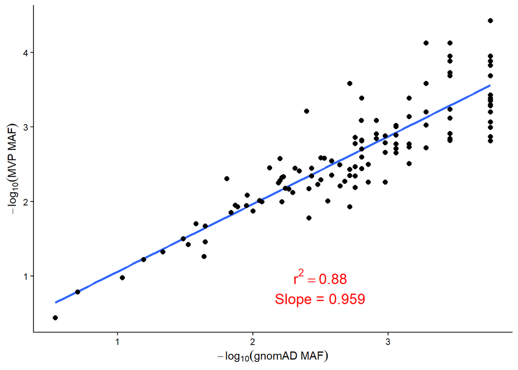

```r
ggp_AMR
```

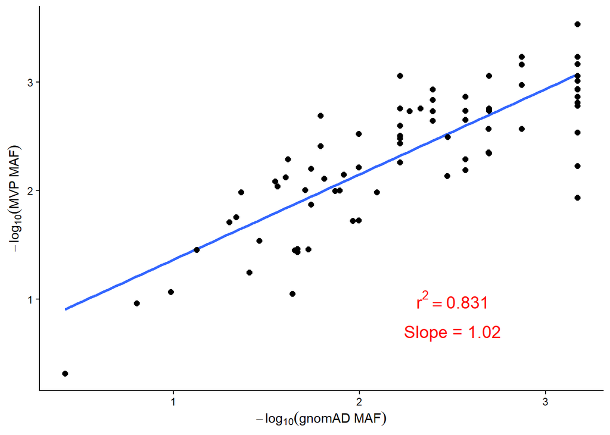

```r
ggp_EAS
```

Save the plots

```r
ggsave(paste0(image_dir, "cor_MAF_gnomAD_EUR.png"),
       plot = ggp_EUR,
       width = 20, height = 10, units = "cm")
ggsave(paste0(image_dir, "cor_MAF_gnomAD_AFR.png"),
       plot = ggp_AFR,
       width = 20, height = 10, units = "cm")
ggsave(paste0(image_dir, "cor_MAF_gnomAD_AMR.png"),
       plot = ggp_AMR,
       width = 20, height = 10, units = "cm")
ggsave(paste0(image_dir, "cor_MAF_gnomAD_EAS.png"),
       plot = ggp_EAS,
       width = 20, height = 10, units = "cm")
```

# ST1 - Binary trait summaries

```r
# Use summaries from Gene-based tests, which don't vary based on SNP missing genotypes
ST1 <-  d_gene_all %>%
  distinct(phecode, description, trait, Ancestry, Subgroup,
           n_cases, observations, prop_cases) %>%
  filter(Subgroup == "All") %>%
  group_by(trait) %>%
  filter(any(n_cases >= 500)) %>%
  ungroup() %>%
  mutate(`# Cases / N (%)` = paste(
    formatC(n_cases, format = "d", big.mark = ","),
    "/",
    formatC(observations,
            format = "d", big.mark = ","),
    paste0("(", round(prop_cases * 100, 1), "%)"),
    sep = " "
  )) %>%
  dplyr::select(-c(n_cases, prop_cases, observations, Subgroup)) %>%
  pivot_wider(names_from = "Ancestry",
              values_from = `# Cases / N (%)`,
              names_prefix = "# Cases / N (%) ") %>%
  left_join(pheinfo) %>%
  dplyr::select(trait = phecode, description, group,
                contains(c("EUR", "AFR", "AMR", "EAS"))) %>%
  mutate(
    description = ifelse(trait == "bmi.obese", "Obesity (BMI >= 30)", description),
    group = ifelse(trait == "bmi.obese", "biomarkers", group)
  ) %>%
  mutate(across(contains(c(
    "EUR", "AFR", "AMR", "EAS"
  )),
  function(x) {
    coalesce(x, "<500")
  }))
```

# ST3 - MTSNV Annotation

```r
anno <-
  readxl::read_xlsx(paste0(analysis_dir, "../hmtvar/Suppl.xlsx"), skip = 1) %>%
  left_join(readxl::read_xlsx(paste0(
    analysis_dir, "../summary/aa_changes.xlsx"
  ))) %>%
  select(-c(EUR, AFR, HIS, ASN, `Variant type`, `aa change`))
ST3 <- anno %>%
  left_join(mvp_afs_wide) %>%
  left_join(gnomad_afs_wide) %>%
  select(
    #basic info
    ID, BP, REF, ALT,
    #Alternative Frequencies
    EUR, AFR, AMR, EAS,
    #more info
    dbSNP,  Locus,  Group, `Variant type` = variant_type,
    `aa change` = aa_change, `Codon position`,
    #Pathogenicity annotations
    Pathogenicity,  `MITOMAP disease`,  `ClinVar disease`,  OMIM,
    #In silico prediction AA substitution consequence
    HmtVar, MutPred,    PANTHER,    `PhD-SNP`,  `Polyphen2 (HumDiv)`,
    `Polyphen2 (HumVar)`,   `SNPs&GO`,
    #Conservation scores
    `PhastCons 100way`, `PhyloP 100way`,
    #Heteroplasmic status
    `1000 Genomes`, MITOMAP,    `MITOMAP (somatic)`,
    # Homoplasmic Allele frequencies from gnomad
    af_hom_EUR, af_hom_AFR, af_hom_AMR, af_hom_EAS,
    # Heterolasmic Allele frequencies from gnomad
    af_het_EUR,  af_het_AFR, af_het_AMR, af_het_EAS
    )
```

# ST4 - Genomic Inflation

```r
ST4 <- d_snp_clean %>%
  select(phecode, description, trait, group, Ancestry, Subgroup, P) %>%
  mutate(chisq = qchisq(1 - P, df = 1)) %>%
  group_by(Ancestry, Subgroup, phecode, trait, description, group) %>%
  summarize(GIF = median(chisq) / qchisq(0.5, df = 1)) %>%
  pivot_wider(names_from = "Ancestry", values_from = "GIF") %>%
  mutate(
    trait = coalesce(biomarker_key[trait], phecode),
    group = ifelse(is.na(group) | group == "", "biomarkers", group),
    description = ifelse(group == "biomarkers", trait, description)
  ) %>%
  ungroup() %>%
  dplyr::select(Subgroup, trait, description, group,
                contains(c("EUR", "AFR", "AMR", "EAS"))) %>%
  arrange(Subgroup, trait)
```

[output not shown]

# ST9b - Hypothyroidism sensitivity analysis

Supplementary table 9b

```r
hypo.sens <-
  fread(paste0(data_dir2, "hypothyroidism_excl_multi.result.txt"))
hypo.tert <-
  fread(paste0(data_dir2, "hypothyroidism_excl_multi.age_tertiles.txt"))

SNPinfo <- all_afreqs %>%
  distinct(ID, POS, REF, ALT)

ST9b <- hypo.sens %>%
  mutate(tertile = "all") %>%
  bind_rows(hypo.tert %>%
              mutate(tertile = as.character(tertile))) %>%
  dplyr::rename(ID = SNP, SE = Std..Error, P = Pr...z..) %>%
  filter(ID != "miniPRS") %>%
  mutate(ID = gsub("_", "-", ID)) %>%
  left_join(SNPinfo) %>%
  inner_join(d_sig_fdr_eur %>%
               filter(phecode == "244.4") %>%
               distinct(POS)) %>%
  mutate(
    `BP/REF/ALT` = paste(POS, REF, ALT, sep = "/"),
    LCI = signif(exp(Estimate - 1.96 * SE), 3),
    UCI = signif(exp(Estimate + 1.96 * SE), 3),
    `OR (95% CI)` = paste0(signif(exp(Estimate), 3), " (", LCI, "-", UCI, ")"),
    `# Cases/N (%)` = paste0(n_cases, "/", observations,
                             " (", round(100 * prop_cases, 1), "%)"),
    P = signif(P, 3)
  ) %>%
  arrange(POS, tertile) %>%
  select(AgeGroup = tertile, `# Cases/N (%)`, ID, `BP/REF/ALT`, `OR (95% CI)`, P)
#ST9b %>% View(.)
```

# ST10 - sex-stratified hypothyroidism

```r
ST10 <- d_sig_fdr_eur %>%
  filter(Ancestry == "EUR" & phecode == "244.4") %>%
  distinct(POS, Ancestry, `Description, Phecode`) %>%
  inner_join(d_snp_fmt) %>%
  filter(Subgroup %in% c("Females", "Males")) %>%
  arrange(POS, Subgroup) %>%
  select(Ancestry, dbSNP, `BP/REF/ALT`, Locus, Sex = Subgroup, `Alt AF`,
         `# Cases / N (%)`, `OR (95% CI), P-value`, `FDR Adjusted P-value`)
```

# ST7 - SNPs in genes

```r
ST7 <- snps_in_SetIDs %>%
  mutate(
    Ancestry = factor(Ancestry, levels = c("EUR", "AFR", "AMR", "EAS")),
    mtsnv = paste0(REF, POS, ALT),
    trait = biomarker_key[trait]
  ) %>%
  arrange(Ancestry, SetID, Subgroup, trait, POS) %>%
  group_by(Ancestry, SetID, Subgroup, trait) %>%
  summarize(`mtSNVs (REF POS ALT)` = paste0(mtsnv, collapse = ", ")) %>%
  arrange(desc(trait == "PheCodes"), Ancestry, SetID, Subgroup)
```

# ST8 - Conditional analysis

```r
ST8 <-
  fread(paste0(data_dir2, "conditional_analysis_mtGeneSNP.txt")) %>%
  mutate(
    Subgroup = case_when(
      POP == "t2d" ~ "T2D",
      POP == "nondiab" ~ "Non-DM",
      SEX != "allsex" ~ str_to_title(SEX),
      TRUE ~ "All"
    ),
    phecode = gsub("_", ".", gsub("phe_", "", trait)),
    `P-value (adjusted for SNV genotype)` = signif(P.value, 3)
  ) %>%
  select(SetID, Ancestry = RACE, phecode, Subgroup,
         `P-value (adjusted for SNV genotype)`) %>%
  inner_join(cond_anly %>% dplyr::rename(SetID = Locus)) %>%
  mutate(
    `Gene P-value` = signif(P.value, 3),
    SNV = paste0("MT", POS)
  ) %>%
  select(Ancestry, Subgroup, SNV, SetID, Phecode = phecode,
         `Phecode Description` = description,
         `Gene P-value`, `P-value (adjusted for SNV genotype)`) %>%
  arrange(desc(Ancestry), desc(Subgroup))
ST8
```

```
##    Ancestry Subgroup    SNV   SetID Phecode            Phecode Description
##      <char>   <char> <char>  <char>  <char>                         <char>
## 1:      EUR      T2D MT3505  MT-ND1   253.2         Pituitary hypofunction
## 2:      EUR      T2D MT1243 MT-RNR1   253.2         Pituitary hypofunction
## 3:      EUR  Females MT9804  MT-CO3  250.42         Other abnormal glucose
## 4:      AFR  Females MT1694 MT-RNR2   276.5                    Hypovolemia
## 5:      AFR  Females MT1694 MT-RNR2     252 Disorders of parathyroid gland
##    Gene P-value P-value (adjusted for SNV genotype)
##           <num>                               <num>
## 1:     7.82e-06                               0.187
## 2:     1.05e-05                               0.704
## 3:     3.25e-05                               0.136
## 4:     1.08e-06                               0.259
## 5:     8.16e-06                               0.631
```

# ST5 - KESER relationships

```r
d_sig_fdr %>%
  distinct(phecode) %>%
  arrange(phecode) %>%
  filter(grepl("\\.", phecode))
```

```
##        phecode
##         <char>
##  1:      244.4
##  2:     250.13
##  3:     250.42
##  4:      253.2
##  5:      253.4
##  6:      255.2
##  7:     255.21
##  8:      259.3
##  9:      260.1
## 10:      271.3
## 11:      275.3
## 12:      276.4
## 13:     276.41
## 14:      276.5
## 15:     427.11
## 16:      428.1
## 17:     440.21
## 18:      452.2
## 19:      457.3
## 20:      573.4
## 21: tg.adj.INT
##        phecode
```

Report the top 5 unique results for each phecode

```r
KESER <- fread(paste0(egress_dir, "KESER.csv"))

ST5 <- KESER %>%
  mutate(Phecode = gsub("PheCode:", "", from)) %>%
  arrange(Phecode, desc(corvalue)) %>%
  # filter out repetitive / non-unique labs/meds (insulin and testosterone)
  filter(!(to.term %in% c("insulin detemir", "insulin glulisine,\n human",
                          "insulin, regular,\n human"))) %>%
  filter(!(from == "PheCode:253.4" & to.term == "other lab:testo-t")) %>%
  filter(!(from == "PheCode:259.3" & to.term %in%
             c("other lab:testost", "other lab:testos", "other lab:tsto",
               "other lab:testos.", "testosterone"))) %>%
  group_by(Phecode) %>%
  slice_head(n=5) %>%
  select(Phecode, everything(), `Cosine Similarity` = corvalue) %>%
  mutate(Phecode = ifelse(row_number() == 1, Phecode, ""))
```

# Export the main tables to word doc

```r
print(tablesdoc, target = paste0(output_dir, "mt_main_tables.docx"))
```

# Export the Supplementary tables to excel

Named according to the order they appear in the manuscript

```r
SuppTables <- list(
  "ST1" = ST1,
  "ST3" = ST3,
  "ST4" = ST4,
  "ST5" = ST5,
  "ST7" = ST7,
  "ST8" = ST8,
  "ST9b" = ST9b,
  "ST10" = ST10
)

# header style
hs1 <- createStyle(textDecoration = "bold", border = "TopBottom")

write.xlsx(
  SuppTables,
  paste0(output_dir, "SuppTablesHelp.xlsx"),
  overwrite = T,
  startRow = 2,
  headerStyle = hs1,
  keepNA = T,
  na.string = "-"
)
```

# Supplementary Methods - Power Simluations

GWAS power based on tutorial: https://cran.r-project.org/web/packages/genpwr/vignettes/vignette.html

Define parameters

```r
# sample sizes
ss <- c(435000, 112000, 54000, 10000)

# with minimum of 500 cases, what are the minimum case proportions
500/ss
```

```
## [1] 0.001149425 0.004464286 0.009259259 0.050000000
```

```r
# for EAS, may want to start at 4 or 5%

# allele frequencies
maf_v = unique(c(
  seq(0.001, 0.005, 0.0002),
  seq(0.005, 0.01, 0.0005),
  seq(0.01, 0.025, 0.001),
  seq(0.025, 0.15, 0.01),
  seq(0.15, 0.45, 0.05)
))

# Colors and labels
crs <- c( 0.002, 0.01, 0.05, 0.1, 0.35)
colorvalues5 = c("purple", "red", "goldenrod",  "green", "blue")
labels5 = c('0.2%', '1%', '5%', '10%', '35%')

# Themes and scales
mytheme <- theme_bw() +
  theme(
    panel.border = element_blank(),
    panel.grid.minor = element_blank(),
    axis.line = element_line(colour = "black")
  )

mycolorscale <- scale_color_manual(name = "% Cases",
                                   values = colorvalues5,
                                   labels = labels5)
```

EUR

```r
orEUR <- genpwr.calc(
  calc = "es",
  model = "logistic",
  ge.interaction = NULL,
  N = ss[1],
  Case.Rate = crs,
  k = NULL,
  MAF = maf_v,
  Power = 0.8,
  Alpha = 1e-5,
  True.Model = c("Additive"),
  Test.Model = c("Additive")
) %>%
  mutate(Case_Rate_fct = factor(Case.Rate, levels = crs))

pEUR <- ggplot(data = orEUR ,
               aes(x = MAF, y = `OR_at_Alpha_1e-05`, color = Case_Rate_fct)) +
  geom_point(size = 3, shape = 23) +
  mytheme + mycolorscale +
  ylab("OR at alpha = 1e-5") +
  ggtitle("EUR, Sample size = 435K, Power = 80%") +
  scale_x_log10()
```

AFR

```r
orAFR <- genpwr.calc(
  calc = "es",
  model = "logistic",
  ge.interaction = NULL,
  N = ss[2],
  Case.Rate = crs,
  k = NULL,
  MAF = maf_v,
  Power = 0.8,
  Alpha = 1e-5,
  True.Model = c("Additive"),
  Test.Model = c("Additive")
) %>%
  mutate(Case_Rate_fct = factor(Case.Rate, levels = crs))

pAFR <- pEUR %+% (orAFR) +
  ylab("OR at alpha = 1e-5") +
  ggtitle("AFR, Sample size = 112K, Power = 80%")
```

AMR

```r
orAMR <- genpwr.calc(
  calc = "es",
  model = "logistic",
  ge.interaction = NULL,
  N = ss[3],
  Case.Rate = crs,
  k = NULL,
  MAF = maf_v,
  Power = 0.8,
  Alpha = 1e-5,
  True.Model = c("Additive"),
  Test.Model = c("Additive")
) %>%
  mutate(Case_Rate_fct = factor(Case.Rate, levels = crs))

pAMR <- pEUR %+% (orAMR) +
  ylab("OR at alpha = 1e-5") +
  ggtitle("AMR, Sample size = 54K, Power = 80%")
```

EAS

```r
orEAS <- genpwr.calc(
  calc = "es",
  model = "logistic",
  ge.interaction = NULL,
  N = ss[4],
  Case.Rate = crs[crs > 0.01],
  #issues with the rarest 2
  k = NULL,
  MAF = maf_v,
  Power = 0.8,
  Alpha = 1e-5,
  True.Model = c("Additive"),
  Test.Model = c("Additive")
) %>%
  mutate(Case_Rate_fct = factor(Case.Rate, levels = crs[crs > 0.01]))

pEAS <- ggplot(data = orEAS ,
               aes(x = MAF, y = `OR_at_Alpha_1e-05`, color = Case_Rate_fct)) +
  geom_point(size = 3, shape = 23) +
  mytheme +
  scale_color_manual(
    name = "% Cases",
    values = c("goldenrod",  "green", "blue"),
    labels = c('5%', '10%', '35%')
  ) +
  ylab("OR at alpha = 1e-5") +
  ggtitle("EAS, Sample size = 10K, Power = 80%") +
  scale_x_log10()
```

Display plots

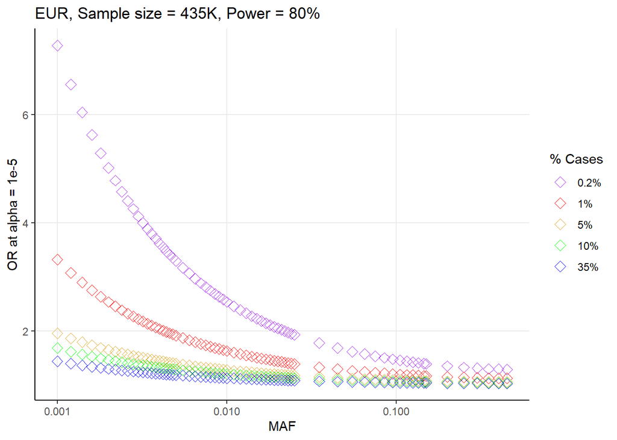

```r
pEUR
```

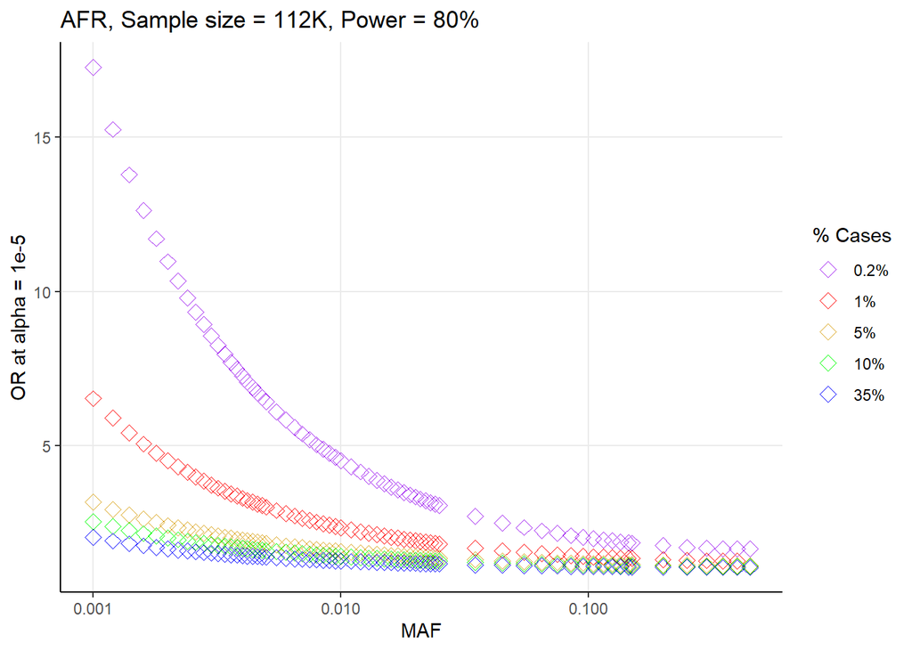

```r
pAFR
```

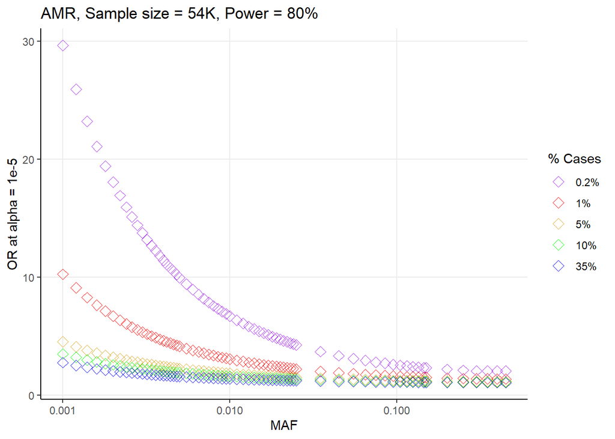

```r
pAMR
```

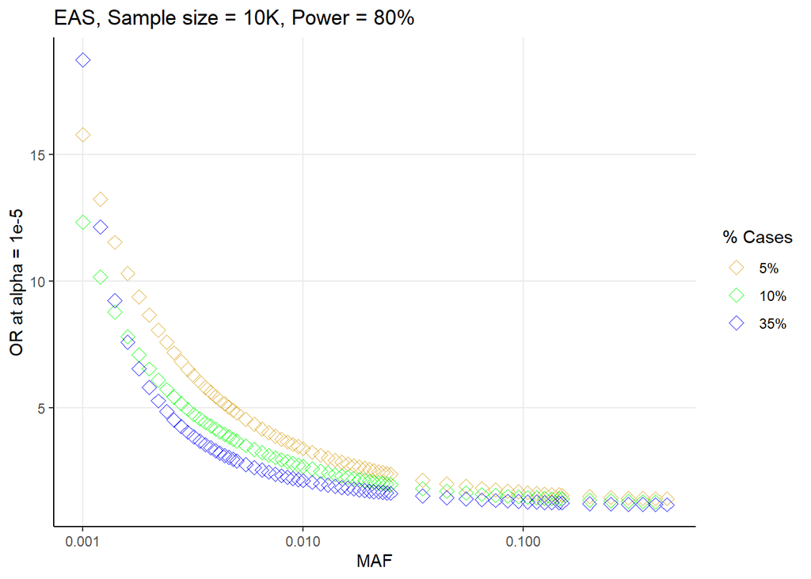

```r
pEAS
```

Combine plots and save

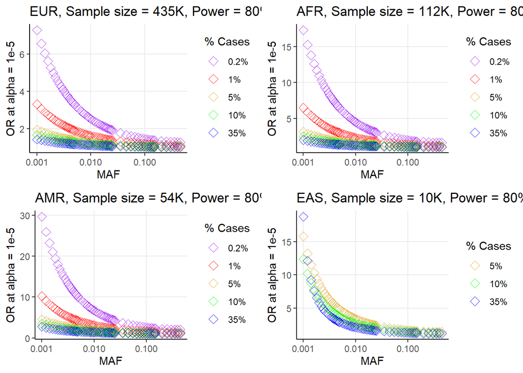

```r
combinedplot <- cowplot::plot_grid(pEUR, pAFR, pAMR, pEAS,
                                   #labels = c('EUR', 'AFR', 'AMR', 'EAS'),
                                   label_size = 12)
combinedplot
```

```r
ggsave(
  paste0(image_dir,
         "powersim_combined_ancestries.png"),
  plot = combinedplot,
  dpi = 300,
  height = 9,
  width = 14
)
```

```r
orEUR %>% filter(MAF == 0.001) %>%
  select(MAF, Case.Rate, `OR_at_Alpha_1e-05`)
```

```
##     MAF Case.Rate OR_at_Alpha_1e-05
## 1 0.001     0.002          7.284750
## 2 0.001     0.010          3.317538
## 3 0.001     0.050          1.956210
## 4 0.001     0.100          1.682197
## 5 0.001     0.350          1.438136
```

```r
orEUR %>%
  filter(Case.Rate == 0.01 & MAF == .01) %>%
  select(MAF, Case.Rate, `OR_at_Alpha_1e-05`)
```

```
##    MAF Case.Rate OR_at_Alpha_1e-05
## 1 0.01      0.01          1.626736
```

```r
orEUR %>%
  filter(Case.Rate == 0.01 & MAF == .001) %>%
  select(MAF, Case.Rate, `OR_at_Alpha_1e-05`)
```

```
##     MAF Case.Rate OR_at_Alpha_1e-05
## 1 0.001      0.01          3.317538
```

Take a look at theoretical power for our significant (main, snp-based) results

EUR

```r
point_data_EUR <- d_sig_fdr %>%
  filter(Subgroup == "All" & Ancestry == "EUR") %>%
  left_join(ORs) %>%
  distinct(MAF = `Alt AF`, lbl = `# Cases / N (%)`, OR)
eur_result_power <- data.frame()
for (i in 1:nrow(point_data_EUR)) {
  r.i <- genpwr.calc(
    calc = "power",
    model = "logistic",
    ge.interaction = NULL,
    N = ss[1],
    Case.Rate = .01*as.numeric(gsub(".*\\(|%\\)", "", point_data_EUR[i, 2])),
    MAF = 0.01*as.numeric(gsub("%", "", point_data_EUR[i, 1])),
    OR = point_data_EUR[i, 3],
    Alpha = 1e-5,
    True.Model = c("Additive"),
    Test.Model = c("Additive")
    )
  eur_result_power <- bind_rows(eur_result_power, r.i)
}

eur_result_power %>%
  select(MAF, OR, Case.Rate, `Power_at_Alpha_1e-05`) %>%
  arrange(desc(`Power_at_Alpha_1e-05`))
```

```
##      MAF      OR Case.Rate Power_at_Alpha_1e-05
## 1 0.1500 1.05861     0.156            0.9942584
## 2 0.1500 1.05484     0.161            0.9850923
## 3 0.2000 1.04761     0.161            0.9772608
## 4 0.2000 1.04740     0.156            0.9707358
## 5 0.1200 1.05837     0.156            0.9701457
## 6 0.0580 1.08069     0.156            0.9654289
## 7 0.0010 3.01437     0.013            0.8148607
## 8 0.0014 4.14782     0.004            0.7558483
```

AFR

```r
point_data_AFR <- d_sig_fdr %>%
  filter(Subgroup == "All" & Ancestry == "AFR") %>%
  left_join(ORs) %>%
  distinct(MAF = `Alt AF`, lbl = `# Cases / N (%)`, OR)
AFR_result_power <- data.frame()
for (i in 1:nrow(point_data_AFR)) {
  r.i <- genpwr.calc(
    calc = "power",
    model = "logistic",
    ge.interaction = NULL,
    N = ss[2],
    Case.Rate = .01*as.numeric(gsub(".*\\(|%\\)", "", point_data_AFR[i, 2])),
    MAF = 0.01*as.numeric(gsub("%", "", point_data_AFR[i, 1])),
    OR = point_data_AFR[i, 3],
    Alpha = 1e-5,
    True.Model = c("Additive"),
    Test.Model = c("Additive")
    )
  AFR_result_power <- bind_rows(AFR_result_power, r.i)
}

AFR_result_power %>%
  select(MAF, OR, Case.Rate, `Power_at_Alpha_1e-05`) %>%
  arrange(desc(`Power_at_Alpha_1e-05`))
```

```
##      MAF      OR Case.Rate Power_at_Alpha_1e-05
## 1 0.0036 3.88064     0.009            0.9021148
## 2 0.0011 7.55481     0.006            0.6915905
```

# Extended PheWAS

### Supplementary Figures 9-11: Manhattan plots

```r
extendedPheWAS_clean <- extendedPheWAS %>%
  filter(n_cases >= 500) %>%
  mutate(
    prop_cases = n_cases / OBS_CT,
    Trait = gsub("_", ".", gsub("phe_", "", trait)),
    `BP/REF/ALT` = str_c(POS, "/", OMITTED, "/", A1, sep = ""),
    `# Cases / N (%)` = ifelse(
      n_cases < 500,
      " < 500",
      paste(
        formatC(n_cases, format = "d", big.mark = ","),
        "/",
        formatC(OBS_CT, format = "d", big.mark = ","),
        paste0("(", round(prop_cases * 100, 1), "%)"),
        sep = " "
      )
    ),
    LCI = signif(L95, 3),
    UCI = signif(U95, 3),
    `OR (95% CI)` = paste0(signif(OR, 3), " (", signif(LCI, 3),
                           "-", signif(UCI, 3), ")"
    )
  ) %>%
  select(-c(POS, OMITTED, A1, REF, ALT, n_cases, OBS_CT, LCI, UCI, L95, U95,
            OR, `LOG(OR)_SE`, SEX, POP, prop_cases, ERRCODE, trait, Z_STAT)) %>%
  dplyr::rename(`Alt AF` = A1_FREQ) %>%
  #reorder
  #select(any_of(names(d_snp_out)), everything()) %>%
  filter(!(Trait %in% ST1$trait)) %>%
  inner_join(pheinfo, by = c("Trait" = "phecode")) %>%
  select(-c(groupnum, color))


unique_plots <- extendedPheWAS_clean %>%
  distinct(`BP/REF/ALT`, ID, Ancestry, Subgroup)
nrow(unique_plots)
```

```
## [1] 35
```

```r
unique_plots %>%
  mutate(mtSNV = paste0("MT", `BP/REF/ALT`)) %>%
  select(mtSNV, Ancestry, Subgroup) %>%
  mutate(Ancestry = factor(Ancestry, levels = c("EUR", "AFR", "AMR"))) %>%
  arrange(Subgroup, Ancestry) %>%
  write_csv(paste0(output_dir, "supp_extPheSNV.csv"))

dir.create(paste0(image_dir, "extManhattan"), showWarnings = FALSE)

d_extPhe_all <- data.frame()
for (i in 1:nrow(unique_plots)) {
  suppressMessages(
    d.i <- unique_plots[i,] %>%
      left_join(extendedPheWAS) %>%
      dplyr::rename( #phenotype = trait,
                    p = P) %>%
      filter(n_cases >= 500) %>%
      mutate(phenotype = gsub("_", ".", gsub("phe_", "", trait))) %>%
      filter(!(phenotype %in% c(ST1$trait))) %>%
      inner_join(pheinfo, by = c("phenotype" = "phecode")) %>%
      mutate(p_FDR = p.adjust(p, method = "fdr"))
  )
  suppressWarnings( fdr_threshold_p <- max(d.i$p[d.i$p_FDR < 0.05]))
  if (is.infinite(fdr_threshold_p)) {
    fdr_threshold_p <- NA
  } else {
    print(paste("FDR threshold for",
                 unique_plots[i,]$Ancestry,
                 unique_plots[i,]$Subgroup,
                 unique_plots[i,]$`BP/REF/ALT`,
                 "is:", signif(fdr_threshold_p, 2)))
    p <- phewasManhattan(d = d.i %>% data.frame(),
                         significant.line = fdr_threshold_p,
                         suggestive.line = NA,
                         annotate.phenotype.description = pheinfo %>%
                           dplyr::rename(phenotype = phecode),
                         annotate.level = fdr_threshold_p,
                         OR.direction = TRUE,
                         y.axis.interval = 1,
                         title = paste(
                           unique(d.i$Ancestry),
                           unique(d.i$Subgroup), "-",
                           unique(d.i$`BP/REF/ALT`))
                         )  +
                         #title = "") +
      theme(    # top, right, bottom, left (in points)
        plot.margin = margin(t = 10, r = 40, b = 10, l = 10))

    ggsave( paste0(image_dir, "extManhattan/",
                   unique(d.i$Ancestry) , "_",
                   unique(d.i$Subgroup) , "_",
                   unique(d.i$POS) , ".png"
                   ),
            plot = p,
            height = 7, width = 11,dpi = 400)
  }
  # Need to export to source data for final submission to NComms
    d_extPhe_all <- bind_rows(d_extPhe_all,
                              d.i %>% data.frame())
}
```

```
## [1] "FDR threshold for AFR Males 5913/G/A is: 5e-05"
```

```
## [1] "FDR threshold for AFR Males 462/C/T is: 2.6e-05"
```

```
## [1] "FDR threshold for AFR Males 827/A/G is: 1.3e-06"
```

```
## [1] "FDR threshold for AMR NonDM 5913/G/A is: 0.00048"
```

```
## [1] "FDR threshold for AMR Males 11172/A/G is: 0.00025"
```

```
## [1] "FDR threshold for AMR Males 12937/A/G is: 2e-04"
```

```
## [1] "FDR threshold for EUR All 10398/A/G is: 6e-05"
```

```
## [1] "FDR threshold for EUR Females 10044/A/G is: 6e-05"
```

```
## [1] "FDR threshold for EUR Females 9804/G/A is: 2.4e-05"
```

# Source Data file needed for final submission Nature Comms

Source data for figures and tables

```r
d_extPhe_less <- d_extPhe_all %>%
  select(ID:A1, A1_FREQ:OR, SE = LOG.OR._SE, n_cases, phenotype, P = p,
         P_FDR = p_FDR, description, group)

SourceData <- list(
  "Figure 1a" = solarplot_afreq$data %>%
    select(-c(OMITTED, ALT_FREQ, MAF)),
  "Figure 1b" = Fig1Helper %>%
    select(-grps) %>% distinct(),
  "Figure 2" = intx_sex_broad %>% select(-c(OR:UCI, POS, phecode)) %>%
    dplyr::rename(`Interaction P-value` = intx_sex_pval),
  "Figure 3" = intx_t2d_broad %>% select(-c(OR:UCI, POS, phecode)) %>%
    dplyr::rename(`Interaction P-value` = intx_t2d_pval),
  "Figure S1" = flowchart_data %>% select(`Box number` = stepno, step, n),
  "Figure S8" = dat_compare %>%
    select(
      ID,
      gnomadID,
      Ancestry_MVP = Ancestry,
      Ancestry_gnomad = id,
      MAF_MVP = MAF_mvp,
      MAF_gnomad = AF_gnomad
    ),
  # Not allowed to share these except via dbGaP
  # "Figure S9" = dat_plot_solargene %>%
  #   select(-c(trait, small_gene:points_sig)),
  "Figure S9" = d_extPhe_less %>% filter(Ancestry == "EUR"),
  "Figure S10" = d_extPhe_less %>% filter(Ancestry == "AFR"),
  "Figure S11" = d_extPhe_less %>% filter(Ancestry == "AMR")
)

SourceDataFile <- paste0(output_dir, "SourceData_NatureComms.xlsx")

write.xlsx(
  SourceData,
  SourceDataFile,
  overwrite = T,
  headerStyle = hs1
)

wb <- loadWorkbook(SourceDataFile)

# Add new worksheets
addWorksheet(wb, "Table 1")
addWorksheet(wb, "Table 2")
addWorksheet(wb, "Table 3")
addWorksheet(wb, "Table 4")

# Write data to the new sheets
writeData(wb, sheet = "Table 1", x = table1a, headerStyle = hs1)
writeData(wb, sheet = "Table 1", x = table1b, headerStyle = hs1, startRow = 14)
writeData(wb, sheet = "Table 1", x = table1c, headerStyle = hs1, startRow = 26)

writeData(wb, sheet = "Table 2", x = snp_table2, headerStyle = hs1)
writeData(wb, sheet = "Table 3", x = Table3, headerStyle = hs1)
writeData(wb, sheet = "Table 4", x = table4 %>% select(-grp1), headerStyle = hs1)

# Save the workbook (overwrite existing file)
saveWorkbook(wb, SourceDataFile, overwrite = TRUE)
```

# Output images to a word doc

```r
body_add_img_auto <- function(doc, img_path, max_width = 9.5, max_height = 7.25) {
  # Read image dimensions
  img_info <- image_info(image_read(img_path))

  # Convert to inches (Word assumes 96 dpi)
  dpi <- 96
  w_in <- img_info$width / dpi
  h_in <- img_info$height / dpi

  # Scale down if wider than max_width
  scaleW <- min(max_width / w_in, 1)
  scaleH <- min(max_height / h_in, 1)
  scale <- min(scaleW, scaleH)

  # Add to document
  doc %>%
    body_add_img(
      src = img_path,
      width = w_in * scale,
      height = h_in * scale
    )
}

img_doc <- read_docx() %>%
  #body_add_par("Table of Contents", style = "heading 1") %>%
  #body_add_break() %>%
  body_add_par("Main", style = "heading 1") %>%
  body_add_break() %>%
  body_add_img_auto(paste0(egress_dir, "SchemaResultsV2025.png")) %>%
  body_add_break() %>%
  body_add_img_auto(paste0(image_dir, "Forestplot_by_sex.png")) %>%
  body_add_break() %>%
  body_add_img_auto(paste0(image_dir, "Forestplot_by_t2d.png")) %>%
  body_add_break() %>%
  body_end_section_landscape() %>%
  body_add_img_auto(paste0(image_dir, "solarplot_afreqs_GIA.png")) %>%
  body_add_break() %>%
  body_add_par("Supplementary", style = "heading 1") %>%
  body_add_img_auto(paste0(image_dir, "flowchart.png")) %>%
  body_add_break() %>%
  body_end_section_portrait() %>%
  body_add_img_auto(paste0(image_dir, "powersim_combined_ancestries.png")) %>%
  body_add_break() %>%
  body_add_img_auto(paste0(image_dir, "combined_fdr_solarplot_genebased.png")) %>%
  body_add_break() %>%
  body_add_par("EUR") %>%
  body_add_img_auto(paste0(image_dir, "cor_MAF_gnomAD_EUR.png")) %>%
  body_add_par("AFR") %>%
  body_add_img_auto(paste0(image_dir, "cor_MAF_gnomAD_AFR.png")) %>%
  body_add_par("AMR") %>%
  body_add_img_auto(paste0(image_dir, "cor_MAF_gnomAD_AMR.png")) %>%
  body_add_par("EAS") %>%
  body_add_img_auto(paste0(image_dir, "cor_MAF_gnomAD_EAS.png")) %>%
  body_add_break()

# Manhattan plots for extended phewas
mhfiles <- list.files(paste0(image_dir, "extManhattan"), full.names=T) %>% sort()
for (i in 1:length(mhfiles)){
  img_doc <- img_doc %>%
    body_add_img(src = mhfiles[i], width = 4, height = 3)
}

img_doc <- img_doc %>%
  body_end_section_landscape()

print(img_doc, target = paste0(output_dir, "images.docx"))
```